# **Introduction to mixed models with `R`**

BCAM - Basque Center for Applied Mathematics, Applied Statistics Research Line

Dae-Jin Lee < dlee@bcamath.org >

Neiker Courses on Statistical Modelling (2016)

# 1 Basic concepts

Many common statistical models can be expressed as linear models that incorporate both fixed effects, which are parameters associated with an entire population or with certain repeatable levels of experimental factors, and random effects, which are associated with individual experimental units drawn at random from a population. A model with both fixed effects and random effects is called a *mixed-effects model*.

Linear mixed-effects models (LMM’s) are an important class of statistical models that can be used to analyze complex data structures. Such data include correlated and/or clustered observations, repeated measurements, longitudinal measurements, multivariate observations, etc. These models are useful in a wide variety of disciplines in the physical, experimental sciences, medicine, psychology, biological and social sciences. They are also known as mixed-effects models as they contain both fixed and random effects. By associating common random effects to observations sharing the same level of a classification factor, mixed-effects models flexibly represent the covariance structure induced by the grouping of the data.

The increasing popularity of mixed-effects models is explained by the flexibility they offer in modeling the within-group correlation often present in grouped data, by the handling of balanced and unbalanced data in a unified framework, and by the availability of reliable and efficient software for fitting them.

There are many packages in `R` with functions that allow LMM’s in various forms. For instance, `amer`, `nlme`, `MASS`, `glmm`, `lmm`, `MCMCglmm`, etc… To facilitate and promote the use of LMM’s in practice, we will provide details for few of them. We focus on `nlme` and `lme4` libraries and functions `lme()` and `lmer()` respectively.

## 1.1 Data types and structures

Mixed-effects models are primarily used to describe relationships between a response variable and some covariates in data that are grouped according to one or more classification factors.

The type of data and its structure determines a first step to know if we need mixed-effects models and how to formulate them.

### 1.1.1 Hierarchical data (grouped data or multilevel)

- The dependent variable is measured once on each individual (unit of interest) and individuals are grouped (or nested) in more than one level.
- Then the units of analysis are usually individuals (at a lower level) who are nested within contextual/aggregate units (at a higher level).
- **Examples:**
  - student in schools.
  - people in districts.
  - patients in hospitals.
  - plants in a plot.

Multilevel structures can be the result of the experimental design. For example, consider a survey to study the health status: we can consider a design with three levels: 1) we sample regions, then 2) districts and finally 3) individuals.

### 1.1.2 Repeated measurements and longitudinal data

- **Repeated measurements** if dependent variable is measured more than once on an individual. *Example:* we measure glucose levels on a patient before and after inyecting insuline. Can be considered as multilevel when *Level 2* indicates the individuals and *Level 1* the measurements taken. Given that measurements are taken on the same individual, probably the observations are not independent, hence a linear model may not be appropiate.
- **Longitudinal studies** involves repeated observations of the same variables over long periods of time. Unlike cross-sectional studies, in which different individuals with same characteristics are compared, longitudinal studies track the same people, and therefore the differences observed in those people are less likely to be the result of cultural differences across generations. Because of this benefit, longitudinal studies make observing changes more accurate, and they are applied in various other fields.

From the mixed-effects perspective the distinction between repeated measurements and longitudinal studies is not so crucial.

## 1.2 Fixed or random effects?

In a mixed-effects model, the key point is to distinguish between **fixed effects** and **random effects**. This is important because the inference and analysis on fixed and random effects is different.

**Fixed effects** are variables associated with an entire population or with certain repeatable levels of experimental factors (*levels* or *treatments*), while **random effects** are associated with individual *experimental units* drawn at random from a population.

**Examples:**

- Consider an experiment where the aim is to compare two groups, 1st group with patients where treatment is applied (case) and a 2nd group where not (control). In this situation, the aim of the study is to compare both groups and not generalize the results for other treatments that might be considered.
- Consider a survey where 10 cities were chosen. If we are interested in the results for those 10 cities and we are not interested in the rest of the cities, the variable *city* is a fixed effect. But if the 10 cities are randomly chosen from a large population of cities we are considering the variable *city* as a random effect.

A measure quantity is considered *random* if it changes over the population units. When a variable is chosen as a random effect in a statistical model, we are assuming that we want to extract conclusions about a population from which the observed units are chosen, but not really from the particular units. Then we can think about *interchangeability*, in the sense that we could have changed a single unit with another one from the population with no effect.

Note that the standard methods used to construct significance tests and confidence intervals for the fixed effects are not valid for the random effects. This is because the observed effects are only a sample of all the possible effects.

Then it is important to distinguish (statistically speaking) between *fixed* and *random* effects if:

- The levels of a variable can be interpreted as extracted from a population with a given probability distribution.
- In the case of a fixed effect, usually we are interested in the comparison of the results for the dependent variable for the different levels of the independent variable, i.e. we are interested in the difference between the averages.
- In the case of the random effects, we are not interested in the difference between the averages, but in how the random effect explains the variability in the dependent variable. Then, to consider an effect as random, we have to find the presence of an un-explained variability associated to the units of the random effect.

## 1.3 Why mixed models?

## 1.4 Some motivating examples

### 1.4.1 Single random factor

- Consider an experimental design in which we have $J$ measurements form each of $I$ units (see next Figure)
- Suppose that we are interested in establishing whether there are differences between the units, but are not really interested in the individuals unit effects.

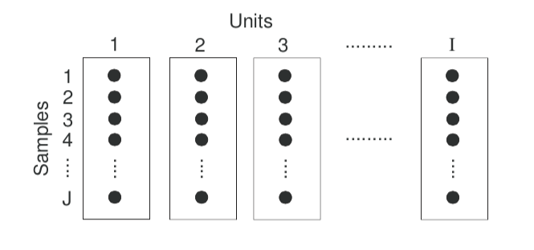

*Schematic illustration of the 1-way or single factor layout. Rectangles are experimental units and $\bullet$’s are measurements.*

### 1.4.2 Railway experiment

*This example is borrowed from Pinheiro and Bates (2000)*

An engineering test for longitudinal stress in rails, involves measuring the time it takes certain ultrasonic waves to travel along the rail. To be a useful test, engineers need to know the average travel time for rails, and the variability to expect between rails, as well as the variability in the measurement process.

Six rails were chosen at random and tested three times each. The only experimental setting that changes between the observations is the rail. We say these observations are arranged in a one-way classification because they are classified according to a single characteristic, the rail on which the observation was made.

```r
library(nlme)
data(Rail)
class(Rail)
```

```
## [1] "nffGroupedData" "nfGroupedData"  "groupedData"    "data.frame"
```

```r
?Rail
Rail$Rail # ordered factor
```

```
##  [1] 1 1 1 2 2 2 3 3 3 4 4 4 5 5 5 6 6 6
## Levels: 2 < 5 < 1 < 6 < 3 < 4
```

The structure of the data is quite simple each row corresponds to one observation for which the rail and the travel time are recorded.

The quantities the engineers were interested in estimating from this experiment are the average travel time for a *typical* rail (the *expected travel time*), the variation in average travel times among rails (the *between-rail variability*), and the variation in the observed travel times for a single rail (the *within-rail variability*).

Data from a one-way classification like the rails example can be analyzed either with a fixed-effects model or with a random effects model. The distinction between the two models is according to whether we wish to make inferences about those particular levels of the classification factor that were used in the experiment or to make inferences about the population from which these levels were drawn.

Data are grouped (or clustered) which implies:

1. observations from the same rail are more similar between them
2. average travel time varies from rail to rail, but also between measurements.

We can see from next Figure that there is considerable variability in the mean travel time for the different rails.

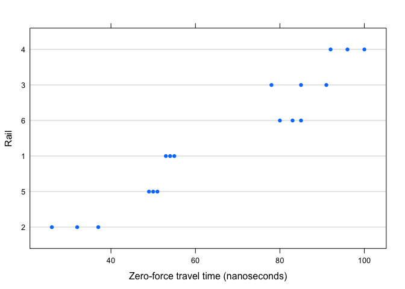

*Travel time in nanoseconds in a sample of six rails.*

```r
plot(Rail)
```

It is evident that we should account for the classification factor when modeling grouped data such as the rails example, we initially ignore the grouping structure of the data and assume the simple *single-mean* model:

$y_{ij} = \mu + \epsilon_{ij}, \qquad i=1,...,M,\quad j=1,...,n_i,\quad \epsilon \sim \mathcal{N}(0,\sigma^2)$ where $y_{ij}$ is the observed travel time for observation $j$ on rail $i$, $\mu$ is the mean travel time across the population of rails being sampled. In this case the number of rails $M=6$ and the number of observation on rail $i$ is $n_i$, i.e. $n_1=n_2=n_3=3$. The total number of observations is $N=\sum_{i=1}^{M} n_i = 18$. We know from theory that the maximum likelihood estimator (MLE) is the sample mean $\bar{y}$ and the mean squared error (MSE) is an estimator of the population variance, i.e. $s^2=\sigma^2$:

```r
mean(Rail$travel)
```

```
## [1] 66.5
```

```r
sd(Rail$travel)
```

```
## [1] 23.64505
```

We fit model with `lm` function as:

```r
rail1 <- lm(travel ~ 1,data=Rail) # single-mean model
summary(rail1)
```

```
##
## Call:
## lm(formula = travel ~ 1, data = Rail)
##
## Residuals:
##    Min     1Q Median     3Q    Max
## -40.50 -16.25   0.00  18.50  33.50
##
## Coefficients:
##             Estimate Std. Error t value Pr(>|t|)
## (Intercept)   66.500      5.573   11.93  1.1e-09 ***
## ---
## Signif. codes:  0 '***' 0.001 '**' 0.01 '*' 0.05 '.' 0.1 ' ' 1
##
## Residual standard error: 23.65 on 17 degrees of freedom
```

The boxplots of the residuals from the ``rail1` fit by rail number is shown as follows. The grouped rail effect is incorporated into the residuals leading to an inflated estimate of the *within-rail* variability.

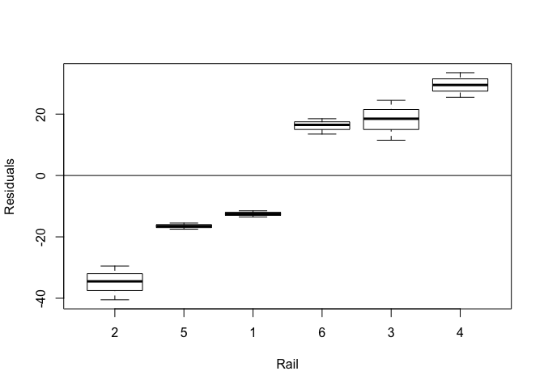

*Boxplot of residuals by number for the `lm` fit the single-mean model.*

```r
boxplot(resid(rail1)~Rail,xlab="Rail",ylab="Residuals",data=Rail)
abline(0,0)
```

The *rail effects* may be incorporated into the model for the travel times by allowing the mean of each rail to be represented by a separate parameter. This fixed-effects model for the one-way classification is written as an ANOVA model as:

$\label{eq:rail2} y_{ij}=\mu_i+\epsilon_{ij},\quad i=1,\ldots , M,\quad j=1,\ldots, n_i \quad \epsilon_{ij}\sim N(0,\sigma^2),$ where $\mu_i$ represents the mean travel time of rail $i$ or also can be viewed as $\mu_i= \mu + \alpha_i$ where $\alpha_i$ is the difference (+ or -) of each individual rail to the overall mean.

```r
 rail2 <- lm(travel~Rail-1, data=Rail)
summary(rail2)
```

```
##
## Call:
## lm(formula = travel ~ Rail - 1, data = Rail)
##
## Residuals:
##     Min      1Q  Median      3Q     Max
## -6.6667 -1.0000  0.1667  1.0000  6.3333
##
## Coefficients:
##       Estimate Std. Error t value Pr(>|t|)
## Rail2   31.667      2.321   13.64 1.15e-08 ***
## Rail5   50.000      2.321   21.54 5.86e-11 ***
## Rail1   54.000      2.321   23.26 2.37e-11 ***
## Rail6   82.667      2.321   35.61 1.54e-13 ***
## Rail3   84.667      2.321   36.47 1.16e-13 ***
## Rail4   96.000      2.321   41.35 2.59e-14 ***
## ---
## Signif. codes:  0 '***' 0.001 '**' 0.01 '*' 0.05 '.' 0.1 ' ' 1
##
## Residual standard error: 4.021 on 12 degrees of freedom
## Multiple R-squared:  0.9978, Adjusted R-squared:  0.9967
## F-statistic: 916.6 on 6 and 12 DF,  p-value: 2.971e-15
```

A `-1` is used in the model formula to prevent the default inclusion of an intercept term in the model. As expected, there is considerable variation in the estimated mean travel times per rail. The residual standard error is $\hat{\sigma}^2=4.021$ (much less than the single-mean model $23.65$).

Looking at the residuals they look centered around zero and have smaller magnitutes, but there are still *some problems*.

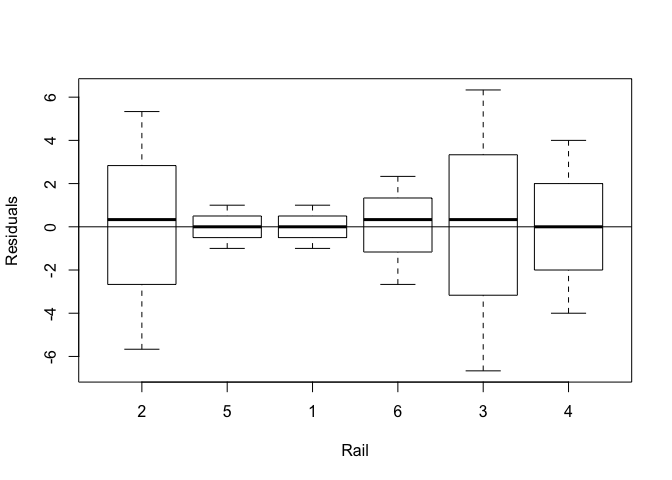

*Boxplot of residuals by rail number for the `lm` fit of the fixed-effects model.*

```r
boxplot(resid(rail2)~Rail,xlab="Rail",ylab="Residuals",data=Rail)
abline(0,0)
```

From `rail2` we see that:

- As expected, there is considerable variation in the estimated mean travel times per rail.
- The residual standard error obtained for the fixed effects model `rail2` is $\hat{\sigma}^2=4.0208$, much lower than the one obtained in the single-mean model `rail1`.
- `rail2` succesfully accounts for the rail effects.
- However, it only models the specific sample of rails used in the experiment, while the main interest is in the population of rails from which the sample was drawn.
- It does not provide an estimate of the *between-rail* variability, which is one of the central quantities of interest in the rails experiment.
- Another drawback of this fixed effects model is that the number of parameters in the model increases linearly with the number of rails.

These issues can be solved with a *random effects* model by treating the rail effects as random variations around a population mean. If we reparameterize one-way classification model `rail2` as

$y_{ij}=\mu+(\mu_i-\mu)+\epsilon_{ij},$

the random effects model replaces the fixed parameters $\mu_i-\mu=u_i$ with a random effect $u_i$, which is a random variable specific for the $i^{\rm th}$ rail, with zero mean and unknown variance $\sigma^2_u$. Once again they are called random effects because they are associated with the particular experimental units (rails in this case that are selected at random from the population of interest). They are effects because they represent a deviation from an overall mean. That is, the *effect* of choosing rail $i$ is to shift the mean travel time from $\mu$ to $\mu+u_i$.

The model would be: $y_{ij}=\mu+u_i+\epsilon_{ij}, \quad u_i\sim \mathcal{N}(0,\sigma^2_u) \quad \epsilon_{ij}\sim \mathcal{N}(0, \sigma^2),$ we also assume that $u_i$’s are *iid* and independent from $\epsilon_{ij}$’s.

Because observations made on the same rail share the same random effect $u_i$, they are correlated (while in the *fixed effects* model they were independent). The covariance between observations on the same rail is $\sigma_u^2$ corresponding to a correlation of $\sigma_u^2/(\sigma_u^2+\sigma^2)$.

The parameters of the statistical model created by the *random effects* model are $\mu$, $\sigma_u^2$ and $\sigma^2$. The number of parameters is always three, irrespective of the number of rails in the experiment. Note that, although the random effects $u_i$ are like parameters we are interested in estimating $\sigma_u^2$. We will however, form prediction $\hat{u}_i$ given the data we observed.

# 2 Mixed model general formulation

In general, linear mixed models (LMM) extend the linear model $\boldsymbol{y} = \boldsymbol{X}\boldsymbol{\beta} + \boldsymbol{\epsilon},\qquad \boldsymbol{\epsilon} \sim \mathcal{N}(0,\sigma^2\boldsymbol{I})$ to

$\boldsymbol{y} = \boldsymbol{X}\boldsymbol{\beta} + \boldsymbol{Z}\boldsymbol{u} + \boldsymbol{\epsilon},\qquad \boldsymbol{u} \sim \mathcal{N}(0,\boldsymbol{G}),\quad \boldsymbol{\epsilon} \sim \mathcal{N}(0,\boldsymbol{R}),$ where $\boldsymbol{X}$ is a $n\times k$ matrix (where $k$ is the number of *fixed effects*), $\boldsymbol{Z}$ is a $n \times p$ matrix ($p$ is the number of *random effects*), $\boldsymbol{G}$ is the variance-covariance matrix of the random effects of dimension $p\times p$. The matrix $\boldsymbol{R}$ is the variance-covariance matrix of the errors usually $\boldsymbol{R} = \sigma^2 \boldsymbol{I}$ but we can assume other forms such as correlation structures.

In our previous rails example, recall that the model for the $j^{\rm th}$ response on the $i^{\rm th}$ rail is $y_{ij} = \mu + u_i + {\epsilon}_{ij},$ where $\begin{array}{ll} y_{ij} & \text{is the observed travel time for observation $j$ on rail $i$}\\ \mu & \text{is the mean travel time across the population of rails sampled}\\ u_i & \text{is the random effect of the $i^{\rm th}$ rail} \\ \epsilon_{ij} & \text{is the error term} \end{array}$ with $u_i$’s and ${\epsilon}_{ij}$ mutually independent.

Hence, the model for the $i^{\rm th}$ rail would be:

$\left ( \begin{array}{c} y_{i1}\\ y_{i2}\\ y_{i3} \end{array} \right )= \left ( \begin{array}{c} 1\\ 1\\ 1 \end{array} \right )~ \mu + \left ( \begin{array}{c} 1\\ 1\\ 1 \end{array} \right )~ u_i +\left ( \begin{array}{c} \epsilon_{i1}\\ \epsilon_{i2}\\ \epsilon_{i3} \end{array} \right )$

or equivalently:

$\boldsymbol{y}_i=\boldsymbol{X}_i~ \boldsymbol{\beta}+ \boldsymbol{Z}_i \boldsymbol{u}_i +\boldsymbol{\epsilon}_i \quad \boldsymbol{u}_i \sim N(0, \sigma^2_u)$

and the model for all the observations would have:

$\boldsymbol{X}=\left ( \begin{array}{c} \boldsymbol{X}_1\\ \boldsymbol{X}_2\\ \vdots \\ \boldsymbol{X}_6 \end{array} \right )~, \quad \boldsymbol{Z}=\left ( \begin{array}{cccc} \boldsymbol{Z}_1 & \boldsymbol{0} & \cdots & \boldsymbol{0}\\ \boldsymbol{0} & \boldsymbol{Z}_2 & \cdots & \boldsymbol{0}\\ & \vdots& \ddots & \vdots \\ \boldsymbol{0} & \boldsymbol{0} & \cdots & \boldsymbol{Z}_6 \end{array} \right ) , \quad \boldsymbol{u}\sim N(\boldsymbol{0}, \boldsymbol{G}) , \quad \boldsymbol{G}=\sigma^2_u \boldsymbol{I}_6 , \quad \boldsymbol{R}=\sigma^2 \boldsymbol{I}_{18}$ i.e.

$\begin{pmatrix} y_{11} \\ y_{12} \\ y_{13} \\ y_{21} \\ y_{22} \\ y_{23} \\ \vdots \\ y_{61} \\ y_{62} \\ y_{63} \\ \end{pmatrix} = \begin{pmatrix} 1 \\ 1 \\ 1 \\ 1 \\ 1 \\ 1 \\ \vdots \\ 1 \\ 1 \\ 1 \\ \end{pmatrix} ~ \mu + \begin{pmatrix} 1 & 0 & 0 & 0 & 0 & 0 \\ 1 & 0 & 0 & 0 & 0 & 0 \\ 1 & 0 & 0 & 0 & 0 & 0 \\ 0 & 1 & 0 & 0 & 0 & 0 \\ 0 & 1 & 0 & 0 & 0 & 0 \\ 0 & 1 & 0 & 0 & 0 & 0 \\ \vdots & \vdots & \vdots & \vdots & \vdots & \vdots \\ 0 & 0 & 0 & 0 & 0 & 1 \\ 0 & 0 & 0 & 0 & 0 & 1 \\ 0 & 0 & 0 & 0 & 0 & 1 \\ \end{pmatrix} ~ \begin{pmatrix} b_1 \\ b_2 \\ b_3 \\ \vdots\\ b_6 \end{pmatrix} + \begin{pmatrix} \epsilon_{11} \\ \epsilon_{12} \\ \epsilon_{13} \\ \epsilon_{21} \\ \epsilon_{22} \\ \epsilon_{23} \\ \vdots \\ \epsilon_{61} \\ \epsilon_{62} \\ \epsilon_{63} \\ \end{pmatrix}$

## 2.1 Estimation of linear mixed models

## 2.2 Estimation of fixed effects

Since linear mixed models are fitted using maximum likelihood estimation, we could, in principle, use generalized likelihood ratio tests for all model comparison/hypothesis testing.

## 2.3 Prediction of random effects

Since the $u_i$’s are random effects, we do not estimate them (they are not parameters), but we predict them (they are random variables). The usual way to do this is to evaluate the expected value of $\boldsymbol{u}$, given the data $\boldsymbol{y}$.

There are several ways to obtain predictions of $\boldsymbol{u}$ such that they are the *best linear unbiased predictors* (BLUP’s). One solution is through *mixed models Henderson equations* obtained maximizing the joint density function of $\boldsymbol{y}$ and $\boldsymbol{u}$:

$f(y,\boldsymbol{u}) = f(\boldsymbol{y} | \boldsymbol{u}) f(\boldsymbol{u}), \quad \boldsymbol{y}|\boldsymbol{u} \sim \mathcal{N}(\boldsymbol{X}\boldsymbol{\beta},\boldsymbol{R}),\quad \boldsymbol{u} \sim \mathcal{N}(0,\boldsymbol{G})$

In terms of the *likelihood* we have $l \propto -\frac{1}{2}\left[log |\boldsymbol{R}|+log |\boldsymbol{G}|+(\boldsymbol{y}-\boldsymbol{X} \boldsymbol{\beta}-\boldsymbol{Z}\boldsymbol{u})^\prime \boldsymbol{R}^{-1}(\boldsymbol{y}-\boldsymbol{X} \boldsymbol{\beta}-\boldsymbol{Z}\boldsymbol{u})+\boldsymbol{u}^\prime \boldsymbol{G}^{-1} \boldsymbol{u} \right],$

deriving w.r.t. $\boldsymbol{\beta}$ and $\boldsymbol{u}$ we obtain the equation:

$\left [ \begin{array}{lc} \boldsymbol{X}^\prime \boldsymbol{R}^{-1} \boldsymbol{X} & \boldsymbol{X}^\prime \boldsymbol{R}^{-1}\boldsymbol{Z}\\ \boldsymbol{Z}^\prime \boldsymbol{R}^{-1} \boldsymbol{X} &\boldsymbol{Z}^\prime \boldsymbol{R}^{-1}\boldsymbol{Z} +\boldsymbol{G}^{-1} \end{array} \right ] \left [ \begin{array}{c} \boldsymbol{\beta} \\ \boldsymbol{u} \end{array} \right ]= \left [ \begin{array}{c} \boldsymbol{X}^\prime \boldsymbol{R}^{-1} \boldsymbol{y}\\ \boldsymbol{Z}^\prime \boldsymbol{R}^{-1} \boldsymbol{y}\\ \end{array} \right ].$

The solution to the system of equations is:

$\hat{\boldsymbol{\beta}}=\left ( \boldsymbol{X}^\prime \boldsymbol{V}^{-1} \boldsymbol{X} \right )^{-1}\boldsymbol{X}^\prime \boldsymbol{V}^{-1} \boldsymbol{y}$ $\hat{\boldsymbol{u}} = \boldsymbol{G} \boldsymbol{Z}^\prime \boldsymbol{V}^{-1} (\boldsymbol{y} -\boldsymbol{X} \hat{\boldsymbol{\beta}}),$ where $\boldsymbol{V}= \boldsymbol{Z} \boldsymbol{G} \boldsymbol{Z}^\prime +\boldsymbol{R}$. However, $\boldsymbol{V}$ depends on variance parameters of $\boldsymbol{G}$ and $\boldsymbol{R}$.

## 2.4 Estimation of the variance components

In general, variance components estimation is done by maximum likelihood (ML) or *restricted/residual maximum likelihood* (REML). See Searle, Casella, and McCulloch (1992) for details.

### 2.4.1 Maximum likelihood

Given $\mbox{Cov}(\boldsymbol{y})=\boldsymbol{V}$ defined as

$\boldsymbol{V} = \boldsymbol{Z}\boldsymbol{G}\boldsymbol{Z}^\prime + \boldsymbol{R}$

The maximum likelihood estimator (MLE) of the variance components in $\boldsymbol{V}$ are based on the model $\boldsymbol{y} \sim \mathcal{N}(\boldsymbol{X}\boldsymbol{\beta},\boldsymbol{V}),$ then $\label{eq:L} l(\boldsymbol{\beta} , \boldsymbol{V}) \propto \frac{1}{2}\left[(\log(|\boldsymbol{V}|) +(\boldsymbol{y}-\boldsymbol{X} \boldsymbol{\beta})^\prime \boldsymbol{V}^{-1}(\boldsymbol{y}-\boldsymbol{X} \boldsymbol{\beta}).\right]$

The MLE of $\boldsymbol{\beta}$ coincides with $\hat{\boldsymbol{\beta}}$. Substituting this expression $l(\boldsymbol{\beta} , \boldsymbol{V})$, we obtain the *profiled* likelihood for $\boldsymbol{V}$: $\label{eq:Lp} l_p(\boldsymbol{V})=\frac{1}{2}\left [(\log |\boldsymbol{V}|+\boldsymbol{y}^\prime \boldsymbol{V}^{-1} \left ( \boldsymbol{I}-\boldsymbol{X}(\boldsymbol{X}^\prime \boldsymbol{V}^{-1} \boldsymbol{X})^{-1} \boldsymbol{X}^\prime \boldsymbol{V}^{-1}\right ) \boldsymbol{y}\right ].$

The MLE of the parameters of $\boldsymbol{V}$ are obtained maximizing $l_p(\boldsymbol{V})$. There is no closed form solution to this maximization problem so an iterative numerical method is used to maximize $l_p$ (or more usually $\log l_p$).

### 2.4.2 Restricted or residual maximum likelihood (REML)

The MLE estimators of variance components tend to become biased, as the number of fixed parameters increases, particularly if sample sizes are not large.

Recall from the classic linear model, the MLE of $\sigma^2$ is $\hat\sigma^2 = \frac{\|\boldsymbol{y}-\hat{\boldsymbol{y}}\|^2}{n}$ The unbiased estimator is $\mathbb{E}(\hat\sigma^2) = \frac{n-k}{n}\sigma^2$ where $k=\mbox{dim}(\boldsymbol{\beta})$. Then, there is a tendency to underestimate variance components, as $k$ increases. The difficulty is that the estimators take no account of the degrees of freedom lost by estimating the fixed effects.

The REML approach Patterson and Thompson (1971) measures the fit of the variance components not from the joint likelihood of the variance parameters and $\boldsymbol{\beta}$, but rather by the (scaled) average of the likelihood over all the possible values of $\boldsymbol{\beta}$. The maximization is done on: $l_R(\boldsymbol{V})= l_P(\boldsymbol{V})-\frac{1}{2}log |\boldsymbol{X}^\prime \boldsymbol{V}^{-1} \boldsymbol{X}|.$

In the railway example:

- **Fixed effects model:** $\hat\mu = 66,5$ and $\hat\sigma = 4,02$
- **Mixed-effects model:** $\hat\mu = 66,5$, $\hat\sigma = 4,02$ and $\hat\sigma_u^2 = 24,80^2$ (with REML and $\hat\sigma_u^2=22,62^2$ with ML)

We will estimate this variance components with `lme` and control options `method="REML"` and `method="ML"`.

# 3 Mixed models estimation with `nlme` and `lme4` `R` packages

There are a large number of `R` packages that can be used to fit LMMs. Rather than attempting to describe all of these packages, we focus mainly on two of them, namely, `nlme` and `lme4`. In this way, we can provide a more detailed account of the tools offered by the two packages, which include a wide variety of functions for model fitting, diagnostics, inference, etc

## 3.1 `lme` function

The main model fitting function in `library(nlme)` is `lme`. A call to the `lme` function is similar to `lm`, except that an extra argument specifying the random effects structure must also be supplied to the model.

`lme` assumes that your data are grouped according to the levels of some factor(s), and that the same random effects structure is required for each group, with random effects independent between groups.

```r
lme(response ~ predictors,random= ,correlation=, method=,data= )
```

The simplest way to specify the random effects structure is with a one sided formula. Suppose a response variable `y` with predictors `x` and `z`, and grouping factor variable `g`. For a single random effect:

```r
lme(y ~ x+z,random = ~1|g,data= df) # default method = "REML"
```

To specify a random effect that depends on a `x`, we must specify `~x|g`

```r
lme(y ~ x+z,random = ~x|g,data= df)
```

A combination of both can be specified as

```r
lme(y ~ x+z,random = ~1+x|g,data= df)
```

Equivalently, we can use the `list` command

```r
lme(y ~ x+z,random = list(g=~1),data= df)
lme(y ~ x+z,random = list(g=~x),data= df)
lme(y ~ x+z,random = list(g=~1+x),data= df)
```

For more than one random effects we use lists, i.e.:

```r
lme(y ~ x+z,random =list(~1|g1,~1|g2),data= df)
```

If random effects are *nested* the `lme` syntax is

```r
lme(y ~ x+z,random =~1|g1/g2,data= df)
```

where factor `g2` is nested in `g1`.

Crossed random effects on the other hand, can be dealt with through a combination of `pdBlocked` and `pdldent` objects.

**Example:** *Rail data*

Now we can easily fit the random effects model with `lme`

```r
library(nlme)
rail3 <- lme(travel~1,random=~1|Rail,data=Rail)
# or equivalently
# rail3 <- lme(travel~1,random=list(Rail=~1),data=Rail)
rail3
```

```
## Linear mixed-effects model fit by REML
##   Data: Rail
##   Log-restricted-likelihood: -61.0885
##   Fixed: travel ~ 1
## (Intercept)
##        66.5
##
## Random effects:
##  Formula: ~1 | Rail
##         (Intercept) Residual
## StdDev:    24.80547 4.020779
##
## Number of Observations: 18
## Number of Groups: 6
```

REML is the default method for estimation, to use ML we have to specify `method="ML"`.

The `summary()` command gives us additional information of the fitted model.

```r
summary(rail3)
```

```
## Linear mixed-effects model fit by REML
##  Data: Rail
##       AIC      BIC   logLik
##   128.177 130.6766 -61.0885
##
## Random effects:
##  Formula: ~1 | Rail
##         (Intercept) Residual
## StdDev:    24.80547 4.020779
##
## Fixed effects: travel ~ 1
##             Value Std.Error DF  t-value p-value
## (Intercept)  66.5  10.17104 12 6.538173       0
##
## Standardized Within-Group Residuals:
##         Min          Q1         Med          Q3         Max
## -1.61882658 -0.28217671  0.03569328  0.21955784  1.61437744
##
## Number of Observations: 18
## Number of Groups: 6
```

```r
model <- rail3
summ  <- summary(rail3)
```

where $\sigma_u = 24.805$ and $\sigma = 4.020$.

Variance components can be obtained by `VarCorr`:

```r
VarCorr(model)
```

```
## Rail = pdLogChol(1)
##             Variance  StdDev
## (Intercept) 615.31111 24.805465
## Residual     16.16667  4.020779
```

Given this information we can compute the intra-class correlation coefficient as: $IIC = \frac{615,31}{615,31+16,16} = 0,974$ i.e. $97,4\%$ of the total variability is due to the heterogeneity between the rails.

We can fit the model by ML

```r
rail3.ml <- update(rail3,method="ML")
VarCorr(rail3.ml)
```

```
## Rail = pdLogChol(1)
##             Variance  StdDev
## (Intercept) 511.86111 22.624348
## Residual     16.16667  4.020779
```

Notice that the ML estimate of $\sigma$ is $4,0208$, the same as the REML estimate (it occurs in simple models but not in general). The ML estimate of $\sigma_u^2=22,624^2$ is smaller than the REML estimate $\sigma_u^2 = 24,805^2$ (this is because ML estimates are not always unbiased, and those for variance components tend to be biased downwards). The estimate of $\hat{\beta}$ are the same $66,5$.

The next table summarizes the `R` syntax to extract results from an `lme` object

| Results | `lme` object |
| --- | --- |
| Estimation method | `model$method` |
| $\hat{\beta}$ coefficients | `fixef(model)` |
| $\hat{\boldsymbol{\beta}}$ $\mathrm{se}(\hat{\boldsymbol{\beta}})$ and t-test | `summary(model)$tTable` |
| $\widehat{\mathrm{Var}}(\hat{\boldsymbol{\beta}})$ | `vcov(model)` |
| I.C. $95\%$ for $\boldsymbol{\beta}$ | `intervals(model, which=''fixed'')` |
| $\hat \sigma$ | `summary(model)$sigma` |
| I.C. $95\%$ for $\sigma,\sigma_u$ | `intervals(model, which=''var-cov'')` |
| $\hat{\boldsymbol{u}}$ | `ranef(model)` |
| $\beta_0+\boldsymbol{u}$ | `coef(model)` |
| $\hat{\boldsymbol{G}}$ | `getVarCov(model)` |
| $\hat{\boldsymbol{G}}$ and $\hat{\sigma}$ | `VarCorr(model)` |
| $\hat{\boldsymbol{R}}$ | `getVarCoc(model,type=''conditional'')` |
| $\hat{\boldsymbol{V}}$ | `getVarCoc(model,type=''marginal'')` |
| $\log$ ML | `logLik(model,REML=FALSE)` |
| $\log$ REML | `logLik(model,REML=TRUE)` |
| AIC | `AIC(model)` |
| BIC | `BIC(model)` |
| Fitted values: | `fitted(model)` |
| Residuals: | `residuals` or `resid` |
| $\; -$ Conditioned | `resid(model,type=''response'')` |
| $\; -$ Marginal | `resid(model, type=''response'',level=0)` |
| Normalized residuals | `resid(model,type=''normalized'')` |
| Pearson residuals | `resid(model, type=''pearson'')` |
| Predicted values: | see `?predict.lme` |
| $\; -$ Conditioned | `predict(model, newdata)` |
| $\; -$ Marginals | `predict(model, newdata,level=0)` |

The fitted model should be examined using graphical and numerical summaries. An initial plot is the one of the residuals versus the fitted responses of the model in order to assess the assumption of constant variance of the $\epsilon_{ij}$.

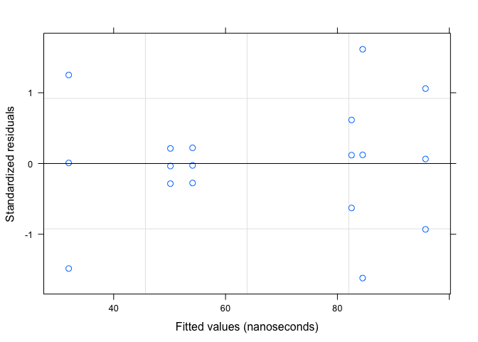

*Standard residuals vs fitted values*

```r
plot(model)
```

Note that standardized residuals in the vertical axis are the raw residuals, $\epsilon_{ij} = y_{ij}-\hat\beta-\hat{u}_{i}$, divided by the estimated standard deviation, $\hat\sigma$, of the $\epsilon_{ij}$.

We should also examine numerical summaries of the model. A basic summary are the confidence intervals on the parameters:

```r
intervals(model)
```

```
## Approximate 95% confidence intervals
##
##  Fixed effects:
##                lower est.    upper
## (Intercept) 44.33921 66.5 88.66079
## attr(,"label")
## [1] "Fixed effects:"
##
##  Random Effects:
##   Level: Rail
##                    lower     est.    upper
## sd((Intercept)) 13.27434 24.80547 46.35341
##
##  Within-group standard error:
##    lower     est.    upper
## 2.695007 4.020779 5.998747
```

We can also assess the significance of the fixed-effects with the `anova` function

```r
anova(model)
```

```
##             numDF denDF F-value p-value
## (Intercept)     1    12 42.7477  <.0001
```

## 3.2 `lmer` function

`lmer` is implemented in the library `lme4`. The mixed-effects model is estimated using a formula with random effects in parenthesis:

```r
lmer( y ~ x+(1|g), data=df)
```

The main difference with `lme` is the limited flexibility in the structure of the covariance matrix $\boldsymbol{G}$.

For the rail example:

```r
library(lme4)
rail.lmer <- lmer(travel ~1+(1|Rail),data=Rail)
summary(rail.lmer)
```

```
## Linear mixed model fit by REML ['lmerMod']
## Formula: travel ~ 1 + (1 | Rail)
##    Data: Rail
##
## REML criterion at convergence: 122.2
##
## Scaled residuals:
##      Min       1Q   Median       3Q      Max
## -1.61883 -0.28218  0.03569  0.21956  1.61438
##
## Random effects:
##  Groups   Name        Variance Std.Dev.
##  Rail     (Intercept) 615.31   24.805
##  Residual              16.17    4.021
## Number of obs: 18, groups:  Rail, 6
##
## Fixed effects:
##             Estimate Std. Error t value
## (Intercept)    66.50      10.17   6.538
```

## 3.3 A randomized design block

*See Pinheiro and Bates (2000) Section 1.2*

In the railway rails example, the observations were classified according to one characteristic only – the rail on which the observation was made. In other experiments we may have more than one classification factor for each observation.

A *randomized block design* is a type of experimentin which there are two classification factors:

- an *experimental factor or treatment*: for which we use fixed effects and
- a *blocking* factor for which we use the random effects.

**Example: ergonometrics experiment with stool types**

The data consists of an ergonometrics experiment that has a randomized block design. The experimenters recorded the effort required (Borg scale) by each of nine different subjects to arise from each of four types of stools.

```r
data(ergoStool)
names(ergoStool)
```

```
## [1] "effort"  "Type"    "Subject"
```

The aim is to compare these four particular types of stools so we used `Type` factor as a fixed effect. The nine different subjects represent a sample from the population about which we wish to make inferences so we use random effects to model the `Subject` factor.

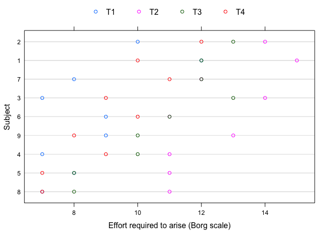

*Effort required (Borg scale) to arise from a stool for 9 different subjects each using 4 different types of stools (T1,T2,T3 and T4).*

```r
plot(ergoStool)
```

From the Figure, we observe that there are systematic differences between stool types.

- `T2` required the greatest effort.
- `T1` was one of the lowest effort types.

The subjects also exhibited variability in their scoring of the effort. `Subject` is a *blocking factor* because it represents a known source of variability in the experiment. `Type` is an *experimental factor* because the purpose of the experiment is to determine if there are systematic differences in the level of effort to arise from the different types of stools.

More summaries:

```r
# results not shown
plot.design(ergoStool)  # Design plot
ergoDF <- as.data.frame(ergoStool)   # convert to data.frame
by(ergoDF$effort, ergoDF$Type,mean)  # averages by Type
by(ergoDF$effort, ergoDF$Subject,mean) # averages by Subject
```

A simple mixed-effects model would be:

$y_{ij} = \mu_j + u_i + \epsilon_{ij}, \quad i=1,2,3,...,9\qquad j=1,2,...,4$ where $\mu_j$ is the fixed effect for the `Type` factor and $u_i$ the random effects for the `Subject` factor.

Adding the term `-1` to the formula for the fixed effects we remove the columns of one’s from the model matrices.

```r
stool.lme <- lme(effort ~ Type-1, random = ~1|Subject,data=ergoStool)
summary(stool.lme)
```

```
## Linear mixed-effects model fit by REML
##  Data: ergoStool
##        AIC      BIC    logLik
##   133.1308 141.9252 -60.56539
##
## Random effects:
##  Formula: ~1 | Subject
##         (Intercept) Residual
## StdDev:    1.332465 1.100295
##
## Fixed effects: effort ~ Type - 1
##            Value Std.Error DF  t-value p-value
## TypeT1  8.555556 0.5760123 24 14.85308       0
## TypeT2 12.444444 0.5760123 24 21.60448       0
## TypeT3 10.777778 0.5760123 24 18.71102       0
## TypeT4  9.222222 0.5760123 24 16.01046       0
##  Correlation:
##        TypeT1 TypeT2 TypeT3
## TypeT2 0.595
## TypeT3 0.595  0.595
## TypeT4 0.595  0.595  0.595
##
## Standardized Within-Group Residuals:
##         Min          Q1         Med          Q3         Max
## -1.80200345 -0.64316591  0.05783115  0.70099706  1.63142054
##
## Number of Observations: 36
## Number of Groups: 9
```

```r
VarCorr(stool.lme)
```

```
## Subject = pdLogChol(1)
##             Variance StdDev
## (Intercept) 1.775463 1.332465
## Residual    1.210648 1.100295
```

To examine the random effects structure, we can compare two models and apply a *likelihood ratio test*, i.e., the hypothesis test is $\mbox{H}_0~:~\sigma_u^2 = 0$. Then:

```r
stool.lm <- lm(effort~Type-1,data=ergoStool) # only fixed effects
test <- -2*logLik(stool.lm) + 2 * logLik(stool.lme,REML=FALSE)
test
```

```
## 'log Lik.' 15.16194 (df=5)
```

```r
mean(pchisq(test,df=c(0,1),lower.tail=FALSE)) # if <0.05 reject H0
```

```
## [1] 4.933627e-05
```

We can also use the `library(RLRsim)`

```r
library(RLRsim)
exactLRT(update(stool.lme,method="ML"),stool.lm)
```

```
##
##  simulated finite sample distribution of LRT. (p-value based on
##  10000 simulated values)
##
## data:
## LRT = 15.162, p-value = 2e-04
```

We can also use AIC (*Akaike Information Criteria*) and select the model with lower AIC

```r
AIC(stool.lm)
```

```
## [1] 147.3064
```

```r
AIC(stool.lme)
```

```
## [1] 133.1308
```

Using the `anova` function we can test the fixed effects, i.e. the hypothesis being tested is $\mbox{H}_0 : \beta_1 = \beta_2 = \beta_3 = \beta_4 = 0,$

which is equivalent to reducing the model to $\boldsymbol{y}_i = \boldsymbol{Z}_i u_i + \boldsymbol{\epsilon}_i, i=1,2,3,...,9\qquad u_i \sim \mathcal{N}(0,\sigma_u^2), \boldsymbol{\epsilon}_i \sim \mathcal{N}(0,\sigma^2\boldsymbol{I})$ That is, eliminates the fixed-effects so the mean response across the population would be zero. Note that, this hypothesis is not meaningful in the context of this experiment.

```r
anova(stool.lme)
```

```
##      numDF denDF  F-value p-value
## Type     4    24 130.5186  <.0001
```

Another option is to compare nested models by likelihood ratio test and ML estimates.:

```r
stool.lme1 <- lme(effort ~ Type,random = ~1|Subject,data=ergoStool,
                  method="ML")
stool.lme0 <- lme(effort ~ 1,random = ~1|Subject,data=ergoStool,
                  method="ML")
anova(stool.lme0,stool.lme1)
```

```
##            Model df      AIC      BIC    logLik   Test L.Ratio p-value
## stool.lme0     1  3 164.1500 168.9006 -79.07502
## stool.lme1     2  6 134.1444 143.6455 -61.07222 1 vs 2 36.0056  <.0001
```

We can examine the parameters estimates

```r
intervals(stool.lme)
```

```
## Approximate 95% confidence intervals
##
##  Fixed effects:
##            lower      est.     upper
## TypeT1  7.366725  8.555556  9.744386
## TypeT2 11.255614 12.444444 13.633275
## TypeT3  9.588947 10.777778 11.966609
## TypeT4  8.033391  9.222222 10.411053
## attr(,"label")
## [1] "Fixed effects:"
##
##  Random Effects:
##   Level: Subject
##                     lower     est.    upper
## sd((Intercept)) 0.7496297 1.332465 2.368453
##
##  Within-group standard error:
##     lower      est.     upper
## 0.8293707 1.1002946 1.4597190
```

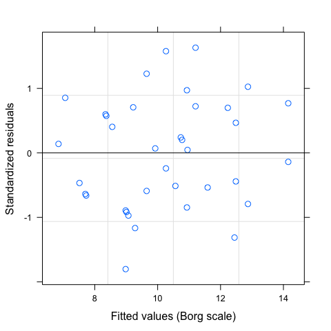

*Plot of fitted values vs standardized residuals*

```r
plot(stool.lme)
```

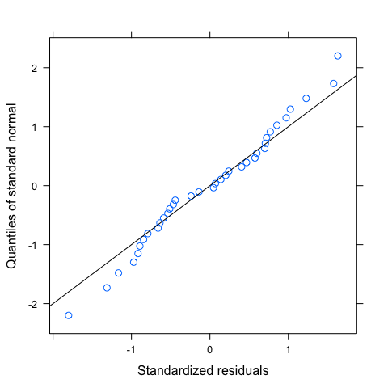

*QQ-plot of standardized residuals*

```r
qqnorm(stool.lme, abline=c(0,1))
```

```r
shapiro.test(resid(stool.lme)) # for a formal normality test
```

```
##
##  Shapiro-Wilk normality test
##
## data:  resid(stool.lme)
## W = 0.97783, p-value = 0.6716
```

**Important:**

- The overall effect of the factor should be assessed with `anova`.
- The interpretation of the parameter estimates for a fixed-effects term depends on the contrasts being used (see `?contrasts`)
- For REML estimation, likelihood ratio tests or comparisons of AIC or BIC require the same fixed-effects structure and the same choice of contrasts in all models.
- Adding `-1` to a model formula or not usually give the same results for `anova`.

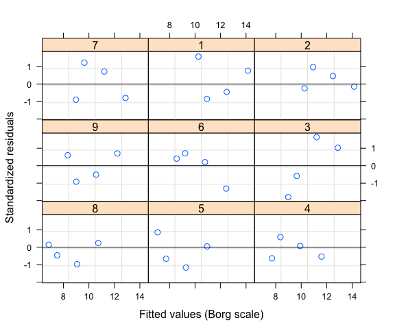

*Standardized residuals vs fitted values by subject*

```r
plot(stool.lme,form=resid(.,type="p") ~ fitted(.)|Subject, abline=0)
```

Estimation using `lmer` function in `library(lme4)`

```r
library(lme4)
stool.lmer <- lmer(effort ~ Type -1 + (1|Subject), data=ergoStool)
ranef(stool.lmer)
```

```
## $Subject
##     (Intercept)
## 8 -1.708716e+00
## 5 -1.495127e+00
## 4 -8.543581e-01
## 9 -2.135895e-01
## 6 -3.283826e-15
## 3  4.271791e-01
## 7  4.271791e-01
## 1  1.708716e+00
## 2  1.708716e+00
```

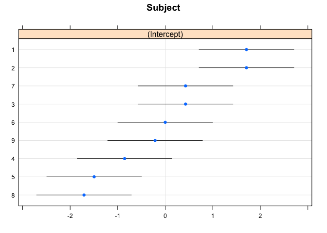

*Random effects plot*

```r
rr1 <- ranef(stool.lmer, condVar = TRUE)
library(lattice)
dotplot(rr1) # or qqmath(rr1)
```

# 4 Multilevel models

**Example: High School and Beyond data set**

High School & Beyond is a nationally representative survey of U.S. public and Catholic high schools conducted by the National Center for Education Statistics (NCES). The data are a subsample of the 1982 HSB survey with 7,185 students from 160 schools. The average sample size per school is approximately 45 students.

```r
MathAchieve <- read.table("data/MathAchieve.txt",header=TRUE,sep="\t")
# Variables
names(MathAchieve)
```

```
## [1] "School"  "Sex"     "SES"     "MathAch" "Sector"  "CSES"
```

```r
str(MathAchieve)
```

```
## 'data.frame':    7185 obs. of  6 variables:
##  $ School : int  1 1 1 1 1 1 1 1 1 1 ...
##  $ Sex    : int  1 1 0 0 0 0 1 0 1 0 ...
##  $ SES    : num  -1.528 -0.588 -0.528 -0.668 -0.158 ...
##  $ MathAch: num  5.88 19.71 20.35 8.78 17.9 ...
##  $ Sector : int  0 0 0 0 0 0 0 0 0 0 ...
##  $ CSES   : num  -1.1 -0.16 -0.1 -0.24 0.27 0.45 -0.19 -0.57 -0.46 -0.03 ...
```

```r
MathAchieve$School <- factor(MathAchieve$School,ordered=FALSE)
MathAchieve$Sex <- factor(MathAchieve$Sex,ordered=FALSE)
levels(MathAchieve$Sex) <- c("Male","Female")
MathAchieve$Sector <- factor(MathAchieve$Sector,ordered=FALSE)
levels(MathAchieve$Sector) <- c("Public","Private")
```

The variable of interest is `MathAch` with $\mathrm{mean}=12.75$ and $\mathrm{std}=6.88$. We created a new variable `CSES` the centered individual `SES`, relative standing on the `SES` measure for a student within school. We need this so that intercept is the mean achievement for the school.

A simple model would estimate the difference in `MathAch` based on the socio-economic status, i.e.: $y_j = \beta_0 + \beta_1 x_j + \epsilon_j,$ This model ignores that the students attends different schools ($j^{\rm th}$ subindex corresponds to the individual unit level).

```r
multilev0 <- lm(MathAch~CSES, data=MathAchieve) # fit a lm
multilev0
```

```
##
## Call:
## lm(formula = MathAch ~ CSES, data = MathAchieve)
##
## Coefficients:
## (Intercept)         CSES
##      12.761        2.191
```

The intercept is $12.76$ and the slope $2.19$.

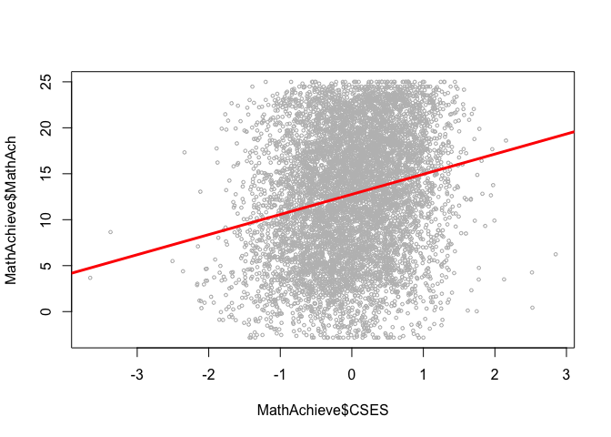

*Linear model fit*

```r
plot(MathAchieve$CSES,MathAchieve$MathAch,cex=.5,col="grey")
abline(multilev0,col=2,lwd=3)
```

Suppose we are interested in comparing differences between schools. $y_{ij} = \beta_{0i} + \beta_1x_{ij} + \epsilon_{ij}$ where the subindex $i$ indicates the school of the student, with $\beta_{0i}$ we specify a separate intercept for each school. Indeed, what we include is a categorical variable with as many categories as schools. Model `multilev1` considers the Schools as a fixed effect, i.e. we implicitly assume that we are interested in the schools of the survey.

```
##
## Call:
## lm(formula = MathAch ~ CSES + School, data = MathAchieve)
##
## Residuals:
##      Min       1Q   Median       3Q      Max
## -18.9903  -4.3986   0.1181   4.5536  18.4433
##
## Coefficients:
##             Estimate Std. Error t value Pr(>|t|)
## (Intercept)  9.72943    0.88731  10.965  < 2e-16 ***
## CSES         2.19117    0.10865  20.168  < 2e-16 ***
## School2      3.79539    1.50582   2.520 0.011742 *
## School3     -2.08142    1.24830  -1.667 0.095478 .
## School4      6.53921    1.62405   4.026 5.72e-05 ***
## School5      3.46067    1.24830   2.772 0.005581 **
## School6      1.48922    1.42155   1.048 0.294859
## School7      0.01140    1.45221   0.008 0.993739
## School8     10.00286    1.35816   7.365 1.97e-13 ***
## School9      8.39553    1.27606   6.579 5.07e-11 ***
## School10     7.12535    1.38155   5.158 2.57e-07 ***
## School11     0.78016    1.19855   0.651 0.515120
## School12     4.51310    1.17651   3.836 0.000126 ***
## School13    -2.05609    1.21882  -1.687 0.091657 .
## School14    -2.69128    1.46896  -1.832 0.066980 .
## School15     6.26771    1.21882   5.142 2.79e-07 ***
## School16     4.70688    1.45221   3.241 0.001196 **
## School17     8.39461    1.43643   5.844 5.32e-09 ***
## School18     3.19204    1.31763   2.423 0.015437 *
## School19     2.36107    1.25485   1.882 0.059938 .
## School20     5.68802    1.18493   4.800 1.62e-06 ***
## School21    -0.41882    1.18066  -0.355 0.722797
## School22     1.42148    1.15742   1.228 0.219437
## School23     6.80235    1.25485   5.421 6.13e-08 ***
## School24     4.26986    1.19855   3.563 0.000370 ***
## School25     0.43064    1.22432   0.352 0.725042
## School26     7.33691    1.19855   6.121 9.77e-10 ***
## School27     3.67997    1.32707   2.773 0.005569 **
## School28     5.19072    1.19855   4.331 1.51e-05 ***
## School29    -3.09987    1.29166  -2.400 0.016425 *
```

[output cut: 122 more lines]

```
## School152    4.95020    1.34730   3.674 0.000240 ***
## School153    0.56404    1.65376   0.341 0.733066
## School154    1.46295    1.43643   1.018 0.308496
## School155    3.82324    1.19855   3.190 0.001430 **
## School156    5.55417    1.21882   4.557 5.28e-06 ***
## School157    0.63890    1.25485   0.509 0.610666
## School158    3.85837    1.35816   2.841 0.004512 **
## School159    1.37278    1.43643   0.956 0.339264
## School160    5.14707    1.18934   4.328 1.53e-05 ***
## ---
## Signif. codes:  0 '***' 0.001 '**' 0.01 '*' 0.05 '.' 0.1 ' ' 1
##
## Residual standard error: 6.083 on 7024 degrees of freedom
## Multiple R-squared:  0.2353, Adjusted R-squared:  0.2178
## F-statistic:  13.5 on 160 and 7024 DF,  p-value: < 2.2e-16
```

We can complicate more the model adding a different socio-economic status for each school, i.e. 1 unit increase of socio-econonomic status can explain different maths achievements in different schools. A model like: $y_{ij} = \beta_{0i} + \beta_{1i}x_{x_{ij}} + \epsilon_{ij}$ now we have the subindex $i$ for the slope $\beta_{1i}$.

We are not interested in these schools in particular, but in the population of schools in order to compare schools with different characteristics.

## 4.1 Multilevel model for group means

Now we consider a data structure with two levels, students are grouped in *Level 1* and in *Level* 2 by `Schools`. Our first model consist on a simple model with no explicative variables, i.e. our only interest is to test the difference between the maths achievements averages among schools.

Next Figure illustrates the variability by schools and within schools (we took a subsample)

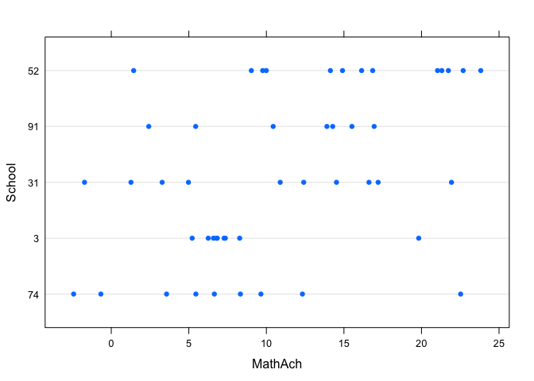

*Subsample of Schools*

```r
attach(MathAchieve)
subMathAchieve=MathAchieve[School==c("91","3","31","52","74"),]
dotplot(reorder(School, MathAch) ~ MathAch,
        subMathAchieve,ylab="School")
```

We specify two levels in the model: $\begin{array}{rclr} y_{ij} & = & \mu_i + \epsilon_{ij} & \mathrm{(Level~1)} \end{array}$ where subindex $j$ corresponds to individuals and $i$ to schools. If we consider the schools as a random effect, then $\mu_i$ (the average of each school) would be given by: $\begin{array}{rclr} \mu_i & = & \beta_0 + u_i & \mathrm{(Level~2)} \end{array}$ where $\beta_0$ is the average of all the students and $u_i$ are deviations of the $i$th school from the total average. Then, the previous equation can be written as: $y_{ij} = \beta_0 + u_i + \epsilon_{ij}, \quad i=1,...,m\quad j=1,...,n_m.$ Indicating that the maths achievement of the $j$th student in the $i$th school is the sum of the overall mean ($\beta_0$), plus the deviation of the $i$th school to the overall mean ($u_i$), plus the deviation of the $j$th student to the average of his/her school ($\epsilon_{ij}$).

In matrix notation the model can be written as:

$\boldsymbol{y}=\boldsymbol{X}\boldsymbol{\beta}+\boldsymbol{Z} \boldsymbol{u}+\boldsymbol{\epsilon}$

$\boldsymbol{y}=\left [ \begin{array}{c} y_{11}\\ \vdots \\ y_{mn_m} \end{array} \right ]\quad \boldsymbol{X}=\left [ \begin{array}{c} \bf1_1\\ \vdots \\ \bf1_m \end{array} \right ] \quad \boldsymbol{Z}=\left [ \begin{array}{cccc} \bf1_1 & 0 &\ldots & 0\\ 0 & \bf1_2 & \ldots & 0\\ \vdots & \vdots & \ddots & \vdots \\ 0 & 0 & \vdots &\bf1_m \end{array} \right ] \quad \bf1_i=\left [ \begin{array}{c} 1\\ 1\\ \vdots \\ 1 \end{array} \right ]_{n_i \times 1}$

The mean of $\boldsymbol{y}$ for the $i$th group is given by $\beta_0+u_i$, then $u_i$ is the deviation of the mean of $i$th group to the total average. Individual level residuals $\epsilon_{ij}$ are the difference between the value of the response variable of the $j$th individual and the average of the group they belong. Next Figure shows the decomposition of the residuals in this model.

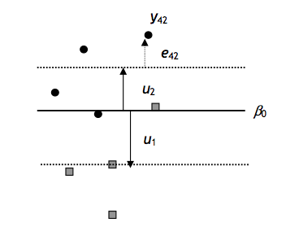

*Illustrative example of residuals decomposition.*

At both levels, we assume $u_i\sim\mathcal{N}(0,\sigma_{u_i}^2)$ and $\epsilon_{ij}\sim\mathcal{N}(0,\sigma^2)$ (both independent).

We fit the model with `lme`

```r
multilev.lme <- lme(MathAch~1,random=~1|School, data=MathAchieve)
multilev.lme
```

```
## Linear mixed-effects model fit by REML
##   Data: MathAchieve
##   Log-restricted-likelihood: -23558.4
##   Fixed: MathAch ~ 1
## (Intercept)
##    12.63697
##
## Random effects:
##  Formula: ~1 | School
##         (Intercept) Residual
## StdDev:    2.934966 6.256862
##
## Number of Observations: 7185
## Number of Groups: 160
```

```r
VarCorr(multilev.lme)
```

```
## School = pdLogChol(1)
##             Variance  StdDev
## (Intercept)  8.614025 2.934966
## Residual    39.148322 6.256862
```

The estimated mean is $12,64$ (`intercept`), and the mean for the $i$th school is $12,64 + \hat{u}_i$ where $\hat{u}_i$ is the predicted random effect for the school.

```r
beta0 <-  fixef(multilev.lme)
beta0
```

```
## (Intercept)
##    12.63697
```

```r
fixef(multilev.lme)-(predict(multilev.lme,
                             newdat=list(School=c("91","3","31","52","74"))))
```

```
##         91          3         31         52         74
## -0.9180495  4.5684656  0.2683476 -2.5377692  3.9073987
## attr(,"label")
## [1] "Predicted values"
```

We can plot the random effects

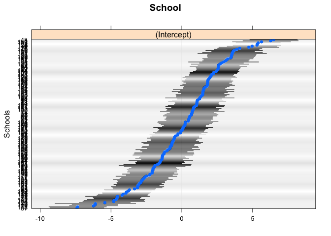

*Random effects and confidence intervals*

If we had considered a fixed effect model, we would get a single variance $\sigma^2 = 6,88^2$ obtained from `summary(multilev.NULL)$sigma`. Considering a random effects model, we have $\sigma_u^2$ and $\sigma^2$, and the total variability of the data would be given by: $\mbox{Var}(y_{ij}) = \sigma^2 + \sigma_u^2$ i.e. the variability within the schools plus the variability among the schools. The intra-class correlation coefficient would be $ICC = \frac{2,93^2}{2,93^2 + 6,27^2} = 0,18$ Then the $18\%$ of the total variability is due to the difference among the averages of the schools.

## 4.2 Constrast for the group effect

A first attempt to contrast if there are differences among groups would be to compute the confidence intervals for $\sigma_u$,

```r
intervals(multilev.lme)
```

```
## Approximate 95% confidence intervals
##
##  Fixed effects:
##                lower     est.    upper
## (Intercept) 12.15789 12.63697 13.11606
## attr(,"label")
## [1] "Fixed effects:"
##
##  Random Effects:
##   Level: School
##                    lower     est.    upper
## sd((Intercept)) 2.595995 2.934966 3.318198
##
##  Within-group standard error:
##    lower     est.    upper
## 6.154239 6.256862 6.361196
```

where `intervals(multilev.lme)$reStruct` does not contain the zero value.

A more formal way to test its significance is by the hypothesis test

$\begin{array}{rl} H_0:& y_{ij}=\beta_0+\epsilon_{ij}\\ H_1:& y_{ij}=\beta_0+u_i+\epsilon_{ij} \end{array}$

which is equivalent to contrast $H_0:~\sigma^2_u=0$. We use *Likelihood Ratio Test* $LR=-2(\log L_0 -\log l_1)$

We can directly estimate the value of the Chi-square statistic or use the function `exactLRT` in `library(RLRsim)`

```
## 'log Lik.' 983.9187 (df=2)
```

```
## [1] 2.810333e-216
```

```
## No restrictions on fixed effects. REML-based inference preferable.
```

```
##
##  simulated finite sample distribution of LRT. (p-value based on
##  10000 simulated values)
##
## data:
## LRT = 983.92, p-value < 2.2e-16
```

So, we reject $H_0$.

The next step is to try to improve the model by including explanatory variables to reduce the variability among schools.

**Model 1: explanatory variable at Level 1**

The explanatory variable is measured at Level 1. Hence, we include it at Level 1 as:

$\begin{array}{rclr} y_{ij} &=& \mu_i + \beta_{1}x_{ij} + \epsilon_{ij} & \mathrm{Level~1} \\ \mu_i &=& \beta_0 + u_i & \mathrm{Level~2} \end{array}$

If $x$ is a continous variable, this model assumes that the slope is the same ($\beta_1$) for all the schools, putting together both equations we have: $y_{ij} = \underbrace{\beta_0 + \beta_1 x_{ij}}_{\rm Fixed~effects} + \underbrace{u_i+\epsilon_{ij}}_{\rm Random~effects}$

In matrix notation:

$\boldsymbol{y}=\boldsymbol{X} \boldsymbol{\beta} + \boldsymbol{Z} \boldsymbol{u} +\boldsymbol{\epsilon}$

$\begin{array}[h]{ccc} \boldsymbol{y}=\left [ \begin{array}{c} y_{11}\\ \vdots \\ y_{mn_m}\\ \end{array} \right ],&\boldsymbol{X}=\left [ \begin{array}{cc} 1&x_{11}\\ \vdots & \vdots\\ 1&x_{mn_m}\\ \end{array} \right ],& \boldsymbol{\beta}=[ \beta_0,\beta_1 ]^\prime \\ & \\ \boldsymbol{Z} = \left [ \begin{array}{cccc} \boldsymbol{1}_{1} & 0 &\ldots &0\\ 0&\boldsymbol{1}_2&\ldots&0 \\ \vdots&\vdots&\ddots&\vdots\\ 0&0&\ldots&\boldsymbol{1}_m\\ \end{array} \right ],&\;\;\;\;\;\;\;\;\;\;\;\; \boldsymbol{1}_j=\left [ \begin{array}{cc} 1\\ 1\\ \vdots\\ 1\\ \end{array}\right ]_{n_j \times 1}& \\ \end{array}$

In this model, the relationship between $\boldsymbol{y}$ and $\boldsymbol{X}$ is represented by a straight line with intercept $\beta_0$ and slope $\beta_1$. However, the intercept for a particular $i$th group is $\beta_0+u_i$, i.e., it is greater or lower than $\beta_0$ by a quantity $u_i$. Although the intercept varies by group the slope is the same for all groups (lines are parallel) (see next Figure).

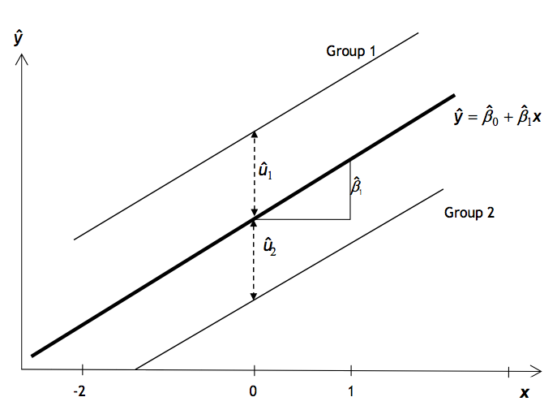

*Illustrative example of fitted global straigth line and lines for each group*

In the example:

```r
 ml1 <- lme(MathAch ~ CSES, random = ~1|School, data=MathAchieve)
 ml1
```

```
## Linear mixed-effects model fit by REML
##   Data: MathAchieve
##   Log-restricted-likelihood: -23362
##   Fixed: MathAch ~ CSES
## (Intercept)        CSES
##   12.649286    2.191168
##
## Random effects:
##  Formula: ~1 | School
##         (Intercept) Residual
## StdDev:    2.944893 6.083618
##
## Number of Observations: 7185
## Number of Groups: 160
```

The fixed effects are

$\beta_0$ is the average math achievement for those students with average socio-economic status. The average straight line is given by:

In order to constrast if the slope is significatively not equal to zero, we need to perform a **Likelihood Ratio Test** for the fixed effects by means of maximum likelihood (ML not REML):

```r
 ml0a <-update(multilev.lme, method="ML")
 ml1a <-update(ml1, method="ML")
anova(ml0a,ml1a)
```

```
##      Model df      AIC      BIC    logLik   Test  L.Ratio p-value
## ml0a     1  3 47121.81 47142.45 -23557.90
## ml1a     2  4 46728.41 46755.93 -23360.21 1 vs 2 395.3969  <.0001
```

The comparison of both models shows that model `ml1` (which includes the socio-economic status covariable `CSES`) reduces the student level variance to a 5% ($(6.25^2-6.08^2)/6.25^2 = 0.05$). The next figure shows the fitted lines for each school:

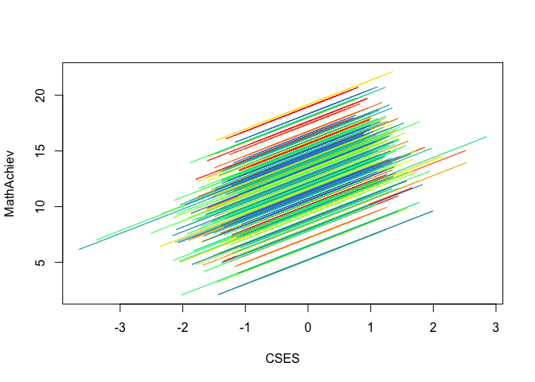

*Fitted lines for each school model*

**Model 2: explanatory variable at Level 2**

If the explanatory variable is measured at Level 2:

$\begin{array}{rclr} y_{ij} & = &\mu_i + \beta_{1}x_{ij} + \epsilon_{ij} & \mathrm{(Level~1)} \\ \mu_i & = &\beta_0 + \beta_{2} s_{i} + u_{i} & \mathrm{(Level~2)} \\ y_{ij} & = &\underbrace{\beta_0 + \beta_{2} s_{i}}_{\text{fixed effects}} + \underbrace{u_i + \epsilon_i}_{\text{random effects}} & \end{array}$

In the example, we include the variable `sector`, i.e.:

```r
 ml2 <- lme(MathAch ~ Sector, random = ~1|School, data=MathAchieve)
 ml2
```

```
## Linear mixed-effects model fit by REML
##   Data: MathAchieve
##   Log-restricted-likelihood: -23540.07
##   Fixed: MathAch ~ Sector
##   (Intercept) SectorPrivate
##     11.393044      2.804887
##
## Random effects:
##  Formula: ~1 | School
##         (Intercept) Residual
## StdDev:    2.583981 6.257108
##
## Number of Observations: 7185
## Number of Groups: 160
```

The estimated model `ml2` shows that the variance of the random effect at Level 2 ($\sigma_u^2$) has decreased ($(2,93^2-2,58^2)/2,93^2 = 0,22$), i.e., the unexplained variability among schools has decreased a $22\%$ when we included the variable `sector`. For the fixed effects we have:

- $\hat{y}~|~\mbox{sector="Public"}= 11.39$
- $\hat{y}~|~\mbox{sector="Private"}= 11.39+2.8=14.19$

Interpreted as follows: *The math achievement of a student of a private school is expected to be 2,8 points higher than for a student in a public school*. This result can be generelized as we have considered a random effect for the schools.

In order to check the significance of the variable `Sector` we performed a likelihood ratio test:

```r
ml2a <- update(ml2, method="ML")
anova( ml0a,ml2a)
```

```
##      Model df      AIC      BIC    logLik   Test  L.Ratio p-value
## ml0a     1  3 47121.81 47142.45 -23557.90
## ml2a     2  4 47087.11 47114.62 -23539.55 1 vs 2 36.70476  <.0001
```

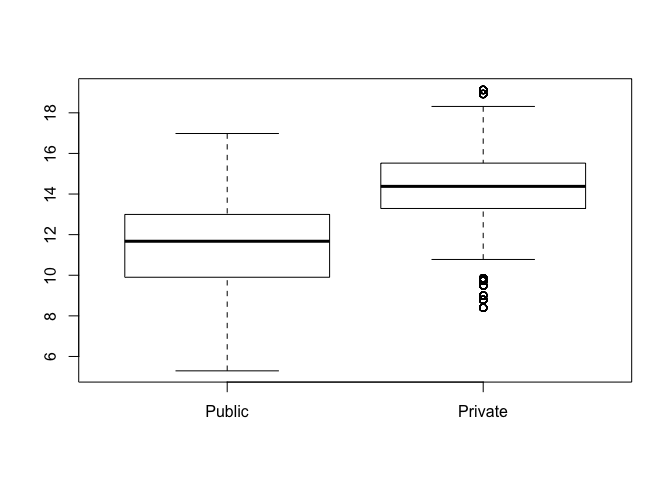

*Boxplot for fitted values by School sector*

## 4.3 Random slopes models

In this type of models, we assume that the relationship between the response variable and the explanatory variables could be different for each of the units at Level 2, i.e. the relationship may change from school to school. We can think for example that the effect of the socio-economic status in math achievements is different among the schools, and then relax the previous model by allowing for a different random slope for all the groups.

**Model 3: explanatory variable at Level 1**

$\begin{array}{rclr} y_{ij} &=& \mu_i + \beta_{1i}x_{ij} + \epsilon_{ij} & \mathrm{(Level~1)} \\ \mu_i &=& \beta_0 + u_{i} & \mathrm{(Level~2)} \\ \beta_{1i} &=& \beta_1 v_i & \end{array}$

$y_{ij}=\underbrace{\beta_0 +\beta_1 x_{ij}}_{\text{fixed effects}}+\underbrace{u_{i}+v_{i}x_{ij}+\epsilon_{ij}}_{\text{random effects}}, \quad \left ( \begin{array}{c} u_i\\ v_i \end{array} \right )\sim N(\boldsymbol{0},\boldsymbol{G}_i)\quad \boldsymbol{G}_i=\left ( \begin{array}{cc} \sigma^2_u & \sigma_{uv}\\ \sigma_{uv} & \sigma^2_v \end{array} \right )$ where $\sigma_{uv}$ is the covariance between the intercepts of the groups and the slopes. A positive value of the covariance implies that groups with high $u_i$ effect tend to have high values of the $v_i$ effect, or equivalently, school with high intercepts have higher slope. In matrix form the model can be written as:

$\boldsymbol{y}=\boldsymbol{X} \boldsymbol{\beta} + \boldsymbol{Z} \boldsymbol{u} +\boldsymbol{\epsilon}$

$\begin{array}[h]{ccc} \boldsymbol{y}=\left [ \begin{array}{c} y_{11}\\ \vdots \\ y_{mn_m}\\ \end{array} \right ],&\boldsymbol{X}=\left [ \begin{array}{c} \boldsymbol{X}_1\\ \vdots \\ \boldsymbol{X}_m\\ \end{array} \right ],& \boldsymbol{X}_i=\left [ \begin{array}{cc} 1&x_{i1}\\ \vdots & \vdots\\ 1&x_{in_i}\\ \end{array} \right ],\\ && \\ \boldsymbol{Z} = \left [ \begin{array}{cccc} \boldsymbol{X}_{1} & 0 &\ldots &0\\ 0&\boldsymbol{X}_2&\ldots&0 \\ \vdots&\vdots&\ddots&\vdots\\ 0&0&\ldots&\boldsymbol{X}_m\\ \end{array} \right ],&\;\;\;\;\;\;\;\;\;\;\;\; \boldsymbol{1}_i=\left [ \begin{array}{cc} 1\\ 1\\ \vdots\\ 1\\ \end{array}\right ]_{n_i \times 1}&\boldsymbol{\beta}=(\beta_0,\beta_1)^\prime . \end{array}$

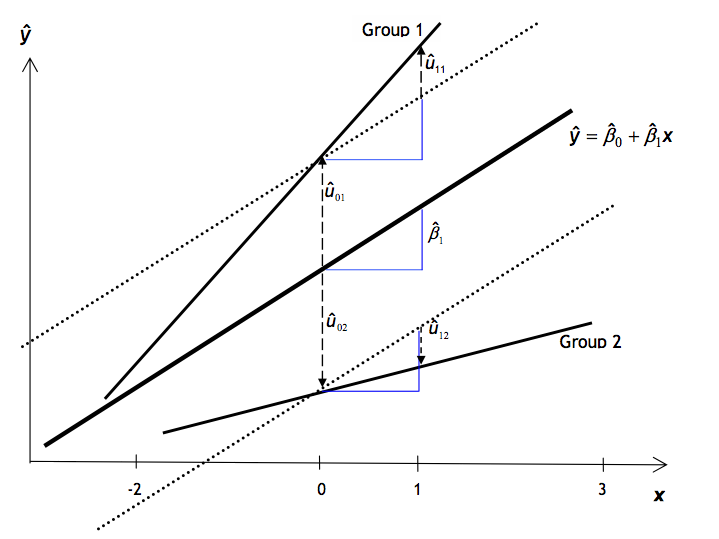

In our example, this previous figure would mean that a increase of the socio-economic status tends to increase the results in both types of schools (public and private), this improvement is higher in school 1 than in school 2, and both difference incresases as long as the socio-economic status incresases.

```r
ml3 <- lme(MathAch ~ CSES, random = ~CSES|School, data=MathAchieve)
ml3
```

```
## Linear mixed-effects model fit by REML
##   Data: MathAchieve
##   Log-restricted-likelihood: -23357.12
##   Fixed: MathAch ~ CSES
## (Intercept)        CSES
##   12.649339    2.193192
##
## Random effects:
##  Formula: ~CSES | School
##  Structure: General positive-definite, Log-Cholesky parametrization
##             StdDev    Corr
## (Intercept) 2.9464629 (Intr)
## CSES        0.8330632 0.021
## Residual    6.0580687
##
## Number of Observations: 7185
## Number of Groups: 160
```

The socio-economic status at school $i$ is estimated as $2,19+\hat{u}_i$ and the variance of the slopes among schools is $0,833^2=0,694$. For the **average school**, we predict an increase of $2,19$ units in the math achievement score when `CSES` increases one unit. The estimated variance are: $\hat{\sigma}^2_{u}=2.946^2=8.67\quad \hat{\sigma}^2_{v}=0.833^2=0.694\quad \hat{\sigma}_{uv}=\rho \sigma_{u} \sigma_{v}= 0.051\quad \hat{\sigma}^2=6.058^2=36.7$

The estimated variance of the intercepts ($\hat{\sigma}^2_{u}=8.67$) is interpreted as the variability among the schools with an average `CSES` . The next figure shows a plot of $\hat{u_i}$ versus $\hat{v_i}$, and it is used to show graphically if there exists a linear relationship between the intercepts and the slopes and decide if an additional term $\sigma_{uv}$ is needed or not.

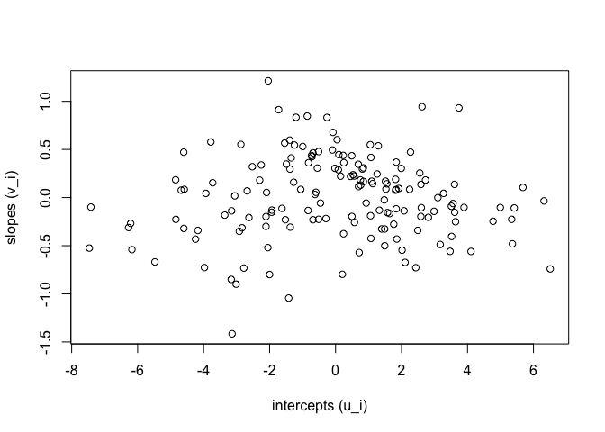

*Random effects plot*

```r
plot(ranef(ml3)[,1],ranef(ml3)[,2],
     xlab="intercepts (u_i)", ylab="slopes (v_i)")
```

```r
ml3a <- lme(MathAch~CSES,random = list(School=pdDiag(~CSES)),
            data=MathAchieve)
anova(ml3a,ml3)
```

```
##      Model df      AIC      BIC    logLik   Test    L.Ratio p-value
## ml3a     1  5 46724.25 46758.65 -23357.12
## ml3      2  6 46726.24 46767.51 -23357.12 1 vs 2 0.01559681  0.9006
```

The next step would be testing if the slopes are different, i.e. $H_0$: $\sigma^2_v=0$, $H_1$: $\sigma^2_v>0$. In this case the LRT is not exact and we need to approximate it by:

```r
test=-2*logLik(ml1, REML=TRUE) +2*logLik(ml3a, REML=TRUE)
mean(pchisq(test,df=c(0,1),lower.tail=FALSE))
```

```
## [1] 0.0008984918
```

We can also use the Akaike Information Criteria to compare the models (the lower the better):

```r
AIC(logLik(ml3))
```

```
## [1] 46726.24
```

```r
AIC(logLik(ml3a))
```

```
## [1] 46724.25
```

```r
AIC(logLik(ml1))
```

```
## [1] 46732
```

The next Figure shows the fitted lines for each school with model `ml3a`

[figure not shown]

*Fitted lines for each school model*

**Model 4: explanatory variables at Level 1 and 2**

$\begin{array}{rclr} y_{ij} &=& \mu_i + \beta_{1i}x_{ij} + \epsilon_{ij} & \mathrm{(Level~1)} \\ \mu_i &=& \beta_0 + \beta_2 s_i + u_i & \mathrm{(Level~2)} \\ \beta_{1i} &=& \beta_1 + \beta_3 s_i + v_i & \end{array}$

$y_{ij}=\underbrace{\beta_0+\beta_1x_{ij}+\beta_2s_i+ \beta_3 x_{ij}:s_i}_{\text{fixed effects}}+ \underbrace{u_{i}+v_{i}x_{ij}+\epsilon_{ij}}_{\text{random effects}}$

As we included a variable measured at Level 2, the fixed part is modified (with respect to Model 3), but the random effect structure remains unchanged. However, one may expect a reduction of the variance components of the random effects, as the unexplained variability is captured by the variable at Level 2. We estimated $\beta_2$ in order to check if the `Private` schools are significatively different to the `Public` schools in terms of average math scores. $\beta_3$ is estimated to check whether `Private` schools differ from `Public` schools in terms of socio-economic status and math scores.

```r
ml4 = lme(MathAch~CSES*Sector,random = list(School=pdDiag(~CSES)),
          data=MathAchieve)
summary(ml4)
```

```
## Linear mixed-effects model fit by REML
##  Data: MathAchieve
##        AIC      BIC    logLik
##   46662.88 46711.03 -23324.44
##
## Random effects:
##  Formula: ~CSES | School
##  Structure: Diagonal
##         (Intercept)      CSES Residual
## StdDev:    2.597427 0.5157795 6.058111
##
## Fixed effects: MathAch ~ CSES * Sector
##                        Value Std.Error   DF  t-value p-value
## (Intercept)        11.409644 0.2929341 7023 38.94952       0
## CSES                2.784446 0.1556796 7023 17.88575       0
## SectorPrivate       2.797268 0.4394370  158  6.36557       0
## CSES:SectorPrivate -1.345710 0.2345135 7023 -5.73830       0
##  Correlation:
##                    (Intr) CSES   SctrPr
## CSES                0.003
## SectorPrivate      -0.667 -0.002
## CSES:SectorPrivate -0.002 -0.664  0.003
##
## Standardized Within-Group Residuals:
##         Min          Q1         Med          Q3         Max
## -3.05497682 -0.73276553  0.01508149  0.75506848  2.99189223
##
## Number of Observations: 7185
## Number of Groups: 160
```

All the fixed effects in model `ml4` are significant. In order to check it we perform a test for the fixed effects:

```r
ml4a <- update(ml4,method="ML")
anova(ml4a)
```

```
##             numDF denDF  F-value p-value
## (Intercept)     1  7023 3393.246  <.0001
## CSES            1  7023  358.710  <.0001
## Sector          1   158   41.233  <.0001
## CSES:Sector     1  7023   33.353  <.0001
```

`Private` schools has an average score significantly higher ($2,79$) and a much lower slope ($-1,34$) than `Public` schools, i.e. in a `Private` school and improvement of the math score is lower than in `Public` schools with respect to the socio-economic status.

The next Figure shows the fitted lines for `Public` and `Private` schoools. It can be noticed that the slopes for `Private` schools are lower that those for `Public` schools.

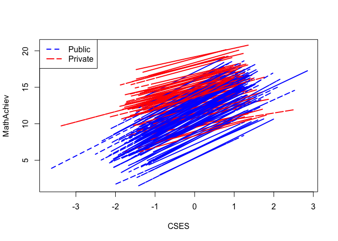

*Fitted lines for each school model*

# 5 Repeated measurements and longitudinal data

The term repeated measures refers to experimental designs (or observational studies) in which each experimental unit (or subject) is measured at several points in time. The term *longitudinal data* is also used for this type of data.

[output not shown]

In the example design just given, we have observed nine short time series, one for each experimental unit. The focus of the analysis would be to determine treatment differences, both in mean level and patterns across time. We may also want to characterize the overall time pattern (assuming that pattern doesn’t differ substantially for different treatments).

Repeated measurements and longitudinal data can be viewed as multilevel models nested among individuals where for example with 2 levels, the lowest level (Level 1) are the repeated measurements nested within individuals (Level 2).

To illustrate these kind of models, we will use data from Singer and Willet (2003) consisting of weight measurements of asian children un the UK. The children were weighted between 1 and 5 times, we also know the sex and the age of the children (`child.txt`).

```r
child <- read.table("data/child.txt",header=TRUE)
```

We can plot the data in order to look the temporal trend.

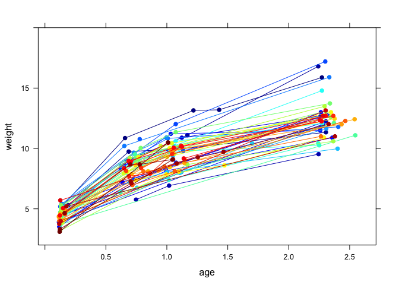

*Plot of children weights and ages*

```r
library(lattice)
library(fields)
xyplot(weight ~ age,groups=id,col=tim.colors(length(unique(child$id))),
       lwd=1,t="b",pch=19,data=child, ylim=c(2,20))
```

Looking at the Figure, we can try to:

1. Linear or quadratic trend
2. Specific intercept for each child
3. Specific straight line for each child

## 5.1 Model with random intercept

We start fitting a model with a quadratic global trend and a random effect for each child. We allow for each child to have an individual trajectory that will be parallel to the mean trajectory.

$\mathrm{weight}_{ij}=\beta_0+ \beta_1\mathrm{age}_{ij}+ \beta_2\mathrm{age}^2_{ij}+u_{i}+\epsilon_{ij}$

```r
# model with random intercept
child.mod1 <- lme(weight~age+I(age^2),random=~1|id,data=child)
child.mod1
```

```
## Linear mixed-effects model fit by REML
##   Data: child
##   Log-restricted-likelihood: -281.0327
##   Fixed: weight ~ age + I(age^2)
## (Intercept)         age    I(age^2)
##    3.432819    7.818011   -1.705631
##
## Random effects:
##  Formula: ~1 | id
##         (Intercept)  Residual
## StdDev:   0.9258152 0.7401676
##
## Number of Observations: 198
## Number of Groups: 68
```

```r
# Equivalently with lmer
child.mod1 <-lmer(weight~age+I(age^2)+(1|id),data=child)
```

We observed a greater variability among individuals than within individuals. A way to explain this is to allow for a difference bewteen the global trajectory and the trajectory for each child would be represented by a line, and the slope of that line varies from child to child.

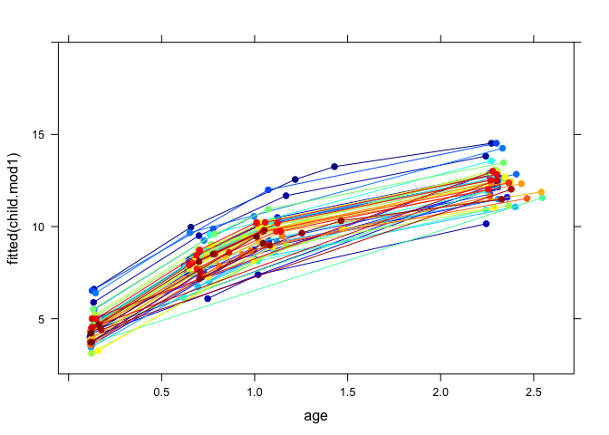

*Fitted model with random intercepts and quadratic trend*

## 5.2 Model with random slopes

The model for the `weight` of the $i$th child at time $j$ is:

$\mathrm{weight}_{ij}=(\beta_0 +u_{i})+ (\beta_1+v_{i})\mathrm{age}_{ij}+\beta_2\mathrm{age}^2_{i}+e_{i},$

$\mathrm{weight}_{ij}=\underbrace{\beta_0 + \beta_1\mathrm{age}_{ij}+ \beta_2\mathrm{age}^2_{ij}}_{\text{fixed}}+\underbrace{u_{i}+v_{i}\mathrm{age}_{ij}+ \epsilon_{ij}}_{\text{random}}$

```r
child.mod2<-lme(weight~age+I(age^2),random=~age|id,
                data=child)
# or with lmer
# child.mod2 <- lmer(weight~age+I(age^2)+(age|id),data=child)
child.mod2
```

```
## Linear mixed-effects model fit by REML
##   Data: child
##   Log-restricted-likelihood: -262.4327
##   Fixed: weight ~ age + I(age^2)
## (Intercept)         age    I(age^2)
##    3.494664    7.703452   -1.660091
##
## Random effects:
##  Formula: ~age | id
##  Structure: General positive-definite, Log-Cholesky parametrization
##             StdDev    Corr
## (Intercept) 0.6459801 (Intr)
## age         0.5116161 0.258
## Residual    0.5780657
##
## Number of Observations: 198
## Number of Groups: 68
```

We can see that the variability within individuals decreased, and there is a positive correlation. We can also test if both parameters are equal to zero or not:

```r
child.mod2a<-lme(weight~age+I(age^2),random = list(id=pdDiag(~age)),
                 data=child)
anova(child.mod2a, child.mod2)
```

```
##             Model df      AIC      BIC    logLik   Test   L.Ratio p-value
## child.mod2a     1  6 537.6541 557.2921 -262.8270
## child.mod2      2  7 538.8654 561.7764 -262.4327 1 vs 2 0.7886937  0.3745
```

The p-value shows that we do not reject the null hypothesis, i.e. correlation is zero. Now, we can contrast if the slopes must be different:

```r
test=-2*logLik(child.mod1, REML=TRUE)+2*logLik(child.mod2a,REML=TRUE)
mean(pchisq(test,df=c(0,1),lower.tail=FALSE))
```

```
## [1] 7.988806e-10
```

The *Likelihood ratio test* shows that we need a model with random slopes. The next figure shows the fitted curves

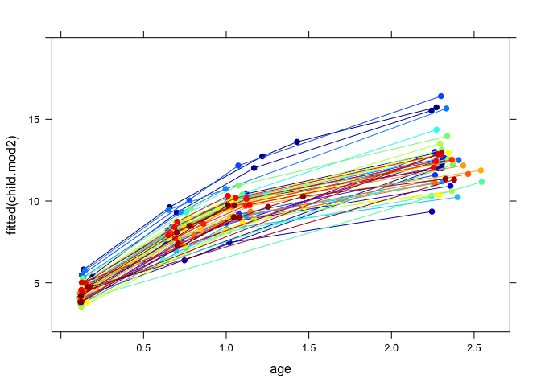

*Fitted model with random intercepts and quadratic trend*

```r
library(fields)
xyplot(fitted(child.mod2) ~ age,groups=id,
       col=tim.colors(length(unique(child$id))),
       lwd=1,t="b",pch=19,data=child,ylim=c(2,20))
```

Is there a different trajectory for boys and girls? We can plot the fitted values separately

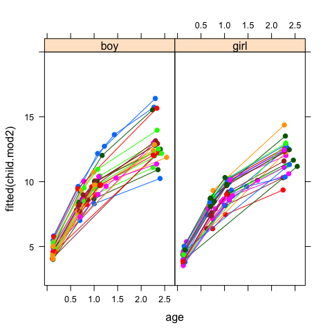

Fitted model with random intercepts and quadratic trend for boys and girls

```r
xyplot(fitted(child.mod2) ~ age|sex,groups=id,lwd=1,t="b",pch=19,
       data=child,ylim=c(2,20))
```

The Figure shows a higher weight average for boys, and also a higher variability among boys that increases as long as the age increases.

A first step is to include the child sex and its interaction with age as a fixed effect in the model, i.e.: $\mathrm{weight}_{ij}=(\beta_0+\beta_3\mathrm{child}_i +u_{i}) + (\beta_1+\beta_4\mathrm{child}_i+v_{i})~\mathrm{age}_{ij}+ \beta_2\mathrm{age}^2_{ij}+\epsilon_{ij},$ i.e. $\mathrm{weight}_{ij}=\beta_0+\beta_1\mathrm{age}_{ij}+\beta_2\mathrm{age}^2_{ij}+ \beta_3\mathrm{sexgirl}_i+ \beta_4(\mathrm{age}_{ij}: \mathrm{child}_i)+u_{i}+v_{j}\mathrm{age}_{ij}+ \epsilon_{ij}$

```r
child.mod3<-lme(weight~age*sex+I(age^2),random=list(id=pdDiag(~age)),
                data=child)
summary(child.mod3)$tTable
```

```
##                  Value  Std.Error  DF    t-value      p-value
## (Intercept)  3.7543813 0.17495268 127  21.459411 4.574972e-44
## age          7.8068688 0.25507768 127  30.605848 1.838193e-60
## sexgirl     -0.5107904 0.21772204  66  -2.346066 2.198582e-02
## I(age^2)    -1.6541318 0.08795207 127 -18.807196 1.608868e-38
## age:sexgirl -0.2296062 0.18099354 127  -1.268588 2.069084e-01
```

The variable sex is significant but the interaction not.

**Interpretation:** On average, boys are heavier than girls, but their average rate of linear growth is not different. How can we check if the interaction is significant?

In the previous model, we included the `sex` effect in the average growth, but we assumed that the variability of the specific deviations of each child were the same between boys and girls. To check if that assumption is reasonable, we introduce the `sex` variable as a random effect to allow the individuals lines to be different from the average for each child sex, i.e.:

$\mathrm{weight}_{ij}=(\beta_0 +\beta_3~\mathrm{sexgirl}_i +u_{i}:\mathrm{sex}_i) + (\beta_1+\beta_4\mathrm{sexgirl}_i+v_{i}:\mathrm{sexgirl}_i)~\mathrm{age}_{ij}+ \beta_2\mathrm{age}^2_{ij}+\epsilon_{ij},$

```r
child.mod4<-lme(weight~age*sex+I(age^2),
                random=list(id=pdDiag(~sex-1),id=pdDiag(~sex:age-1)),
                data=child)
print(child.mod4)
```

```
## Linear mixed-effects model fit by REML
##   Data: child
##   Log-restricted-likelihood: -254.9944
##   Fixed: weight ~ age * sex + I(age^2)
## (Intercept)         age     sexgirl    I(age^2) age:sexgirl
##   3.7672164   7.7820066  -0.5150251  -1.6399541  -0.2428170
##
## Random effects:
##  Formula: ~sex - 1 | id
##  Structure: Diagonal
##            sexboy   sexgirl
## StdDev: 0.5763521 0.7727271
##
##  Formula: ~sex:age - 1 | id %in% id
##  Structure: Diagonal
##         sexboy:age sexgirl:age  Residual
## StdDev:  0.7012966   0.2678847 0.5588593
##
## Number of Observations: 198
## Number of Groups:
##           id id.1 %in% id
##           68           68
```

```r
summary(child.mod4)$tTable
```

```
##                  Value  Std.Error  DF    t-value      p-value
## (Intercept)  3.7672164 0.16548522 127  22.764670 1.176554e-46
## age          7.7820066 0.26279169 127  29.612834 7.272974e-59
## sexgirl     -0.5150251 0.22134640  66  -2.326783 2.305571e-02
## I(age^2)    -1.6399541 0.08673299 127 -18.908078 9.738796e-39
## age:sexgirl -0.2428170 0.17769546 127  -1.366478 1.742033e-01
```

For all the previous models in this section, we assumed that the residuals at the lowest level $\epsilon_{ij}$ were independents. In the next Section we will see how we can relax that assumption.

# 6 Extensions of the linear mixed model

## 6.1 Heteroskedasticity

Until now, we have assumed mixed models with constant variance such that:

$\boldsymbol{y}=\boldsymbol{X} \boldsymbol{\beta} +\boldsymbol{Z} \boldsymbol{u} +\boldsymbol{\epsilon} , \quad Var(\boldsymbol{\epsilon})=\sigma^2\boldsymbol{I}$

This assumption does not hold in many situations:

- When the variance increases as long as the magnitude of the response variable increases.
- When the variances are different for each group.
- When the variability depends on the explanatory variable.

In those situations, a better option is to model the variance as a functions of the covariates, a grouping factor or the mean of the response, i.e.:

$Var(\epsilon_{ij})=\sigma^2g^2(\boldsymbol{v}_i,\boldsymbol{\theta})$ where

$\begin{array}{rcl} {v}_i &=& \text{ is a vector of one or more covariates (including $E[y_{ij}]$) } \\ \boldsymbol{\theta} &=& \text{ a vector of unknown parameters to be estimated }\\ g^2(.) &=& \text{ a known functions} \end{array}$ The library `lme4` does not include these option, instead we have to use `nlme` library.

**Available functions in `library(nlme)`**

- `varFixed` The variance function is $g^2(\boldsymbol{v}_i)=\boldsymbol{v}_i$: $Var(\epsilon_{ij})=\sigma^2\boldsymbol{v}_i$ the variance is proportional to the values of the covariate (also known as *weighted least squares*).
- `varIdent` It corresponds to specifying different variances for each level of the grouping factor, $\boldsymbol{s}$. The variance function is $g^2(s_{ij},\boldsymbol{\theta})=\theta_{s_{ij}}$: $Var(\epsilon_{ij})=\sigma^2 \theta^2_{s_{ij}}$
- `varPower` It is a generalization of `varFixed`, the error variance is a power of the absolute value of the variance covariate: $g^2(\boldsymbol{v}_i)=|\boldsymbol{v}_i|^{2\theta}$, and $Var(\epsilon_{ij})=\sigma^2|\boldsymbol{v}_i|^{2\theta}$ A particular case is when the covariate is the mean, i.e.: $Var(\epsilon_{ij})=\sigma^2=|\boldsymbol{mu}_i|^{2\theta}$
- `varComb` It allow the combination of two, or more, variance models by multiplying together the corresponding variance functions.

**Example:** *Body Weight Growth in Rats*

This example describes data on the body weights of rats measured over 64 days. The body weights of the rats (in grams) are measured on day 1 and every seven days thereafter until day 64, with an extra measurement on day 44. The experiment started several weeks before `day 1.` There are three groups of rats, each on a different diet.

```r
library(nlme)
data(BodyWeight)
head(BodyWeight)
```

```
## Grouped Data: weight ~ Time | Rat
##   weight Time Rat Diet
## 1    240    1   1    1
## 2    250    8   1    1
## 3    255   15   1    1
## 4    260   22   1    1
## 5    262   29   1    1
## 6    258   36   1    1
```

Figure show plots of the body weights versus time by diet. The plots indicate strong differences among the three diet groups. There is one rat with a high initial weight in group 2. The weight increases linearly with time. We can consider a model with different intercepts and different slopes for each diet group and random effects to account for the variability among rats.

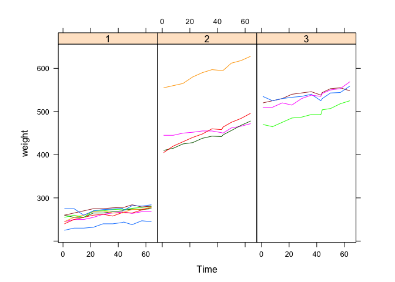

Body weights of rats by Time and Diet

An initial model would be:

```r
# create a centered variable cTime
BodyWeight$cTime <- BodyWeight$Time - mean(BodyWeight$Time)
rat1 <- lme(weight~cTime*Diet, data=BodyWeight,random=~cTime|Rat)
rat1
```

```
## Linear mixed-effects model fit by REML
##   Data: BodyWeight
##   Log-restricted-likelihood: -575.8599
##   Fixed: weight ~ cTime * Diet
## (Intercept)       cTime       Diet2       Diet3 cTime:Diet2 cTime:Diet3
## 263.7159091   0.3596391 220.9886364 262.0795455   0.6058392   0.2983375
##
## Random effects:
##  Formula: ~cTime | Rat
##  Structure: General positive-definite, Log-Cholesky parametrization
##             StdDev     Corr
## (Intercept) 36.6355112 (Intr)
## cTime        0.2484113 0.077
## Residual     4.4436052
##
## Number of Observations: 176
## Number of Groups: 16
```

Results of the model `rat1` shows that the variability of the intercepts is much higher than the variability of the slopes. A first step is to check whether there exists an interaction between `Diet` and `Time` and if it is necessary to allow for different slopes for each rat.

```r
rat1a <- update(rat1,method="ML")
rat1b <- lme(weight~cTime+Diet, data=BodyWeight,random=~cTime|Rat,
             method="ML")
anova(rat1b,rat1a)
```

```
##       Model df      AIC      BIC    logLik   Test  L.Ratio p-value
## rat1b     1  8 1194.219 1219.583 -589.1095
## rat1a     2 10 1185.858 1217.563 -582.9291 1 vs 2 12.36078  0.0021
```

Hence the interaction is significant.

```r
rat1.1 <- lme(weight~cTime*Diet, data=BodyWeight,
              random = list(Rat=pdDiag(~cTime)))
anova(rat1.1,rat1)
```

```
##        Model df      AIC      BIC    logLik   Test    L.Ratio p-value
## rat1.1     1  9 1169.792 1198.014 -575.8959
## rat1       2 10 1171.720 1203.078 -575.8599 1 vs 2 0.07195708  0.7885
```

```r
# Null model
Model_NULL <- lme(weight~cTime*Diet, data=BodyWeight,
                  random=~1|Rat) # rat1

# LRT
test=-2*logLik(Model_NULL, REML=TRUE) +2*logLik(rat1.1, REML=TRUE)

# p-value
mean(pchisq(test,df=c(0,1),lower.tail=FALSE))
```

```
## [1] 1.488156e-19
```

And hence, we need different slopes for each rat.

In previous models, we have assumed that intercepts and slopes had the same variability per group. Next plot shows the clear within-group heteroscedasticity.

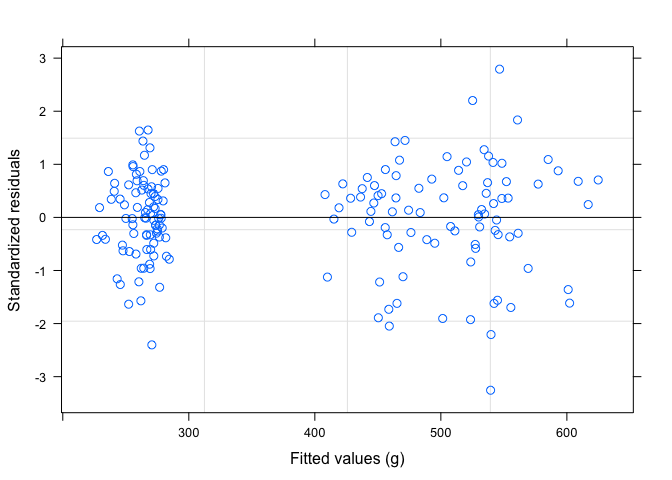

*Plot of standardized residuals versus fitted values for the homoscedastic model*

```r
plot(rat1.1)
```

Because the fitted values are bounded away from zero, we can use the `varPower` variance function to model the heteroscedasticity.

```r
rat2 <- update(rat1.1,weights=varPower(form=~fitted(.)))
rat2
```

```
## Linear mixed-effects model fit by REML
##   Data: BodyWeight
##   Log-restricted-likelihood: -570.9949
##   Fixed: weight ~ cTime * Diet
## (Intercept)       cTime       Diet2       Diet3 cTime:Diet2 cTime:Diet3
## 263.7150249   0.3610754 220.9652249 262.0741998   0.6014446   0.2952008
##
## Random effects:
##  Formula: ~cTime | Rat
##  Structure: Diagonal
##         (Intercept)     cTime  Residual
## StdDev:    36.61393 0.2435684 0.1749746
##
## Variance function:
##  Structure: Power of variance covariate
##  Formula: ~fitted(.)
##  Parameter estimates:
##     power
## 0.5430376
## Number of Observations: 176
## Number of Groups: 16
```

The residuals variance has decreased (from $4.443$ to $0.175$).

The plot of the standardized residuals versus the fitted values for the heteroscedastic fit corresponding to `rat2` indicates that the `varPower` variance function adequately represents the within-group heteroscedasticity.

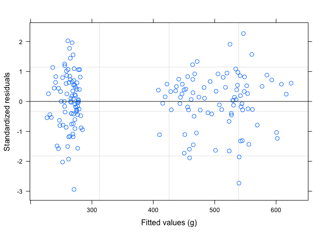

*Plot of standardized residuals versus fitted values for the `varPower` model*

```r
plot(rat2)
```

We can test the significance of the variance parameter ($\theta=0$)

```r
anova(rat1.1,rat2)
```

```
##        Model df      AIC      BIC    logLik   Test  L.Ratio p-value
## rat1.1     1  9 1169.792 1198.014 -575.8959
## rat2       2 10 1161.990 1193.348 -570.9949 1 vs 2 9.801898  0.0017
```

The primary question of interest for the rats data is whether the growth rates differ significantly among diets.

```r
summary(rat2)
```

```
## Linear mixed-effects model fit by REML
##  Data: BodyWeight
##       AIC      BIC    logLik
##   1161.99 1193.348 -570.9949
##
## Random effects:
##  Formula: ~cTime | Rat
##  Structure: Diagonal
##         (Intercept)     cTime  Residual
## StdDev:    36.61393 0.2435684 0.1749746
##
## Variance function:
##  Structure: Power of variance covariate
##  Formula: ~fitted(.)
##  Parameter estimates:
##     power
## 0.5430376
## Fixed effects: weight ~ cTime * Diet
##                 Value Std.Error  DF   t-value p-value
## (Intercept) 263.71502 12.950705 157 20.362985   0e+00
## cTime         0.36108  0.088349 157  4.086917   1e-04
## Diet2       220.96522 22.437479  13  9.848042   0e+00
## Diet3       262.07420 22.438653  13 11.679587   0e+00
## cTime:Diet2   0.60144  0.155375 157  3.870915   2e-04
## cTime:Diet3   0.29520  0.155844 157  1.894210   6e-02
##  Correlation:
##             (Intr) cTime  Diet2  Diet3  cTm:D2
## cTime        0.000
## Diet2       -0.577  0.000
## Diet3       -0.577  0.000  0.333
## cTime:Diet2  0.000 -0.569  0.000  0.000
## cTime:Diet3  0.000 -0.567  0.000  0.000  0.322
##
## Standardized Within-Group Residuals:
##         Min          Q1         Med          Q3         Max
## -2.93954908 -0.44396488  0.07709085  0.60043464  2.26745821
##
## Number of Observations: 176
## Number of Groups: 16
```

`summary(rat2)` only provide tests for differences between Diet 1 (reference group) and Diet 2 and between Diet 1 and Diet 3. We can test the difference in growth rates between Diets 2 and 3 using the `anova` method.

```r
anova(rat2, L=c("cTime:Diet2"=1,"cTime:Diet3"=-1))
```

```
## F-test for linear combination(s)
## cTime:Diet2 cTime:Diet3
##           1          -1
##   numDF denDF  F-value p-value
## 1     1   157 2.857771  0.0929
```

The argument `L` is used to specify constrats of coefficients to be tested as equal to zero. There does not seem to be a significant difference in growth rate between Diets 2 and 3.

**Orthodont data**

Investigators at the University of North Carolina Dental School followed the growth of 27 children (16 males, 11 females) from age 8 until age 14. Every two years they measured the distance between the pituitary and the pterygomaxillary fissure, two points that are easily identified on x-ray exposures of the side of the head.

```r
data(Orthodont)
```

Next Figure shows the data with the individual linear regression fits by sex groups.

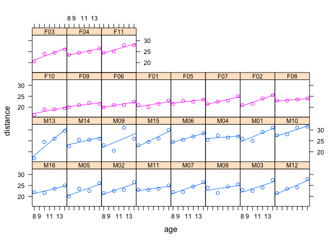

*Orthodont data with individual `lm` fits*

```r
xyplot(distance~age | Subject, groups=Sex,
       data=Orthodont,type=c("p","r"),
       par.strip.text=list(cex=0.75), layout=c(8,4))
```

A very simple practical way to check whether the slopes are different is to compare two samples, i.e.:

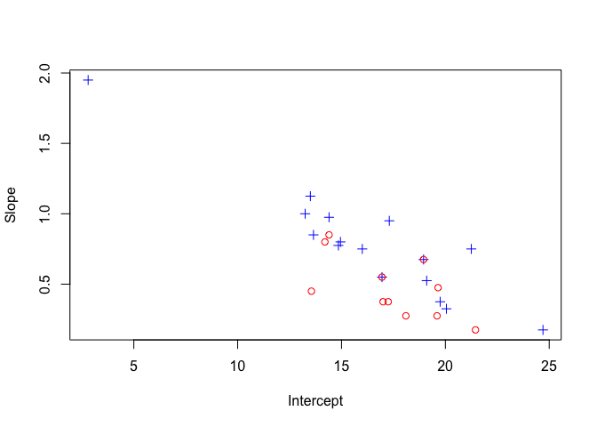

Plot of intercepts VS slopes by sex group

```r
ab <- t(sapply(split(Orthodont, Orthodont$Subject),
        function(u)coef(lm(distance~age, data=u))))
ab <- cbind(ab, data.frame(Sex=sapply(split(as.character(Orthodont$Sex),
Orthodont$Subject),function(x)x[1])))

names(ab) <- c("ybar", "b", "Sex")

sex <- as.character(ab$Sex)

plot(ab[, 1], ab[, 2], col=c(Female="red", Male="blue")[sex],
     pch=c(Female=1, Male=3)[sex], xlab="Intercept", ylab="Slope")
```

```r
#lmList.obj <- lmList(distance~age|Subject,data=Orthodont)
#coef(lmList.obj)
#plot(intervals(lmList.obj))
#plot(coef(lmList.obj)[,1],(coef(lmList.obj)[,2]),xlab= "Estimated slope",
# ylab="Estimated intercept",pch=c(Female=1, Male=3)[sex], col=c(Female="red", Male="blue")[sex])
```

```r
attach(ab)
t.test(b[Sex=="Male"], b[Sex=="Female"], var.equal=TRUE)
```

```
##
##  Two Sample t-test
##
## data:  b[Sex == "Male"] and b[Sex == "Female"]
## t = 2.2624, df = 25, p-value = 0.03261
## alternative hypothesis: true difference in means is not equal to 0
## 95 percent confidence interval:
##  0.02733691 0.58232218
## sample estimates:
## mean of x mean of y
## 0.7843750 0.4795455
```

```r
detach("ab")
```

The p-value is less than $5\%$ and hence we reject $H_0$ (that the slopes are equal).

Now we consider a random effects model. First, we assume a model with the same slope for both groups and second a model with different slopes for males and females.